# MAMBA FINE TUNING

Authors

- Andrea Bonomi (a.bonomi021@studenti.unibs.it)
- Giorgio Bucella (g.bucella002@studenti.unibs.it)
- Riccardo Rossi-Erba (r.rossierba@studenti.unibs.it)

# Introduction

- The project began with an in-depth study of the **Mamba architecture**, a language model based on **State Space Models (SSMs)** rather than transformers.
  - While transformers remain the dominant paradigm, **Mamba demonstrates efficiency and scalability** through alternative design principles.
  - Commercial applications, such as **Mistral’s Codestral**, highlight Mamba’s practical relevance for specialized tasks like **code generation**.
- After reviewing **Mamba 2**, the most efficient implementation of this architecture, the research focused on evaluating **performance in a constrained environment** (Google Colab), starting with the **smallest model versions**.
  - Implemented and assessed different **fine-tuning techniques** across various scales.
  - Comparisons were made against results reported in the original reference paper.
- Environment setup included:
  - Tokenizer configuration.
  - Evaluation metrics via **LM-eval** to ensure reproducibility and benchmark consistency.
  - Dedicated functions for fine-tuning procedures to enhance clarity and repeatability.
- Experiments focused on two datasets:
  - **PiQA**
  - **ARC-e**
- Fine-tuning strategies employed:
  - **Supervised Fine-Tuning (SFT)**
  - **Direct Preference Optimization (DPO)**
  - **LoRA** parameter-efficient fine-tuning
- All experiments were conducted using the **Hugging Face platform**, providing tools for:
  - Model management
  - Dataset handling
  - Efficient training workflows
- The final stage will **compare the results of fine-tuned models** with larger baseline models on the same datasets, highlighting performance gains and efficiency trade-offs.

# Preliminary operations

## Install libraries

- We use Google Drive as our main storage space
- It is easy and convenient to connect to the Colab development environment.

```python
from google.colab import drive
drive.mount('/content/drive')
```

- The Colab development environment gave us some initial problems with installing libraries.
- After trying a few configurations, we found one that allowed us to install what we needed and get it working without any major incompatibility issues.
- The versions that worked for our development environment are listed in the cell below.

```python
!pip install --upgrade pip

!pip install torch==2.7.1 torchvision==0.22.1 torchaudio==2.7.1 --index-url https://download.pytorch.org/whl/cu118
!pip install transformers==4.55.0

# working libraries with Python 3.12, cuda 12.4 in the colab environment
# other environments were not tested
!wget https://github.com/Dao-AILab/causal-conv1d/releases/download/v1.5.2/causal_conv1d-1.5.2+cu11torch2.7cxx11abiTRUE-cp312-cp312-linux_x86_64.whl
!wget https://github.com/state-spaces/mamba/releases/download/v2.2.5/mamba_ssm-2.2.5+cu11torch2.7cxx11abiTRUE-cp312-cp312-linux_x86_64.whl

!pip install /content/causal_conv1d-1.5.2+cu11torch2.7cxx11abiTRUE-cp312-cp312-linux_x86_64.whl
!pip install /content/mamba_ssm-2.2.5+cu11torch2.7cxx11abiTRUE-cp312-cp312-linux_x86_64.whl
```

- The following libraries, on the other hand, did not cause any incompatibility issues and it was not necessary to “fix” the versions.

```python
!pip install lm-eval
!pip install trl
!pip install wandb
```

- For training logs we use [Weight&Bias](https://wandb.ai/site/) (wandb).

```python
import torch
import wandb

device = "cuda" if torch.cuda.is_available() else "cpu"
api_key = '588615f4ac9462bac4948707c716915ae51cc81f'
wandb.login(key=api_key)
```

## Set up the Tokenizer

- The tokenizer used is based on the pre-trained [GPT-NeoX-20B](https://huggingface.co/docs/transformers/model_doc/gpt_neox) model, with 20 billion parameters.
- This tokenizer is common to all models.
- It is the one used by the Mamba authors to evaluate the models.

This [script](https://github.com/state-spaces/mamba/blob/main/evals/lm_harness_eval.py) shows the use of the tokenizer `"EleutherAI/gpt-neox-20b"`.

```python
from transformers import AutoTokenizer

tokenizer = AutoTokenizer.from_pretrained("EleutherAI/gpt-neox-20b")
tokenizer.pad_token_id = tokenizer.eos_token_id
```

## Result analysis functions

```python
from lm_eval import evaluator
from lm_eval.models.huggingface import HFLM
import matplotlib.pyplot as plt
import pandas as pd
from datetime import timedelta
```

### Plotting and Printing fine tuning log

- These functions provide tools to retrieve, clean, and visualize training data from Weights & Biases (W&B) runs a posteriori, once the run is finished.
  - `print_run_duration` reports the total runtime of an experiment.
  - `get_sft_train_df` and `get_dpo_train_df` extract and organize training/evaluation histories for supervised fine-tuning (SFT) and direct preference optimization (DPO).
  - `plot_sft_results` and `plot_dpo_results` generate plots of loss curves (and accuracy for DPO), offering a quick view of training dynamics.
  - `print_sft_table` and `print_dpo_table` display aligned training and evaluation metrics in markdown tables alongside runtime. Altogether, they simplify performance tracking and comparison across fine-tuning runs.

```python
wandb_user = '' # insert your wandb user name here
wandb_project = ''# insert your wandb project name here
```

```python
def print_run_duration(wandb_run_id):
    api = wandb.Api()
    run = api.run(f'{wandb_user}/{wandb_project}/{wandb_run_id}')
    runtime_seconds = run.summary.get("_runtime", None)

    print(f'Run duration: {str(timedelta(seconds=runtime_seconds))}')
```

```python
def get_sft_train_df(wandb_run_id):
  wandb_run_name = f'r-rossierba-universit-degli-studi-di-brescia/mamba2/{wandb_run_id}'
  api = wandb.Api()
  run = api.run(wandb_run_name)
  history = run.history()

  # clean the dataframes
  eval_loss_history = history[history['eval/loss'].notna()]
  eval_loss_history = eval_loss_history.drop(columns=[col for col in eval_loss_history.columns if col not in ['eval/loss', 'train/global_step', 'train/epoch']])

  train_loss_history = history[history['train/loss'].notna()]
  train_loss_history = train_loss_history.drop(columns=[col for col in train_loss_history.columns if col not in ['train/loss', 'train/global_step']])

  return eval_loss_history, train_loss_history

def plot_sft_results(wandb_run_id):
  eval_loss_history, train_loss_history = get_sft_train_df(wandb_run_id)

  fig, axes = plt.subplots(1, 2, figsize=(12, 6), sharex=True)

  axes[0].plot(eval_loss_history['train/global_step'], eval_loss_history['eval/loss'], label='Eval Loss', color='orange')
  axes[0].set_title('Eval Loss')
  axes[0].legend()

  axes[1].plot(train_loss_history['train/global_step'], train_loss_history['train/loss'], label='Train Loss', color='red')
  axes[1].set_title('Train Loss')
  axes[1].legend()

  for ax in axes.flat:
      ax.set_xlabel('Global Step')
      ax.grid(True)

  plt.tight_layout()
  plt.show()

def print_sft_table(wandb_run_id):
  print(f'Run id: {wandb_run_id}\n')
  eval_loss_history, train_loss_history = get_sft_train_df(wandb_run_id)
  train_loss_history = train_loss_history[train_loss_history['train/global_step'].isin(eval_loss_history['train/global_step'])]
  merged_df = pd.merge(train_loss_history, eval_loss_history, on='train/global_step')
  merged_df = merged_df[['train/epoch','train/global_step', 'train/loss', 'eval/loss']]
  merged_df.columns = ['Epoch', 'Step', 'Train Loss', 'Eval Loss']
  merged_df = merged_df.round(4)
  print_run_duration(wandb_run_id)
  print(merged_df.to_markdown(index=False))
```

```python
def get_dpo_train_df(wandb_run_id):
  wandb_run_name = f'r-rossierba-universit-degli-studi-di-brescia/mamba2/{wandb_run_id}'
  api = wandb.Api()
  run = api.run(wandb_run_name)
  history = run.history()

  # clean the dataframes
  eval_loss_history = history[history['eval/loss'].notna()]
  eval_loss_history = eval_loss_history.drop(columns=[col for col in eval_loss_history.columns if col not in ['eval/loss', 'train/global_step', 'train/epoch', 'eval/rewards/accuracies']])

  train_loss_history = history[history['train/loss'].notna()]
  train_loss_history = train_loss_history.drop(columns=[col for col in train_loss_history.columns if col not in ['train/loss', 'train/global_step']])

  return eval_loss_history, train_loss_history

def plot_dpo_results(wandb_run_id):
  eval_loss_history, train_loss_history = get_dpo_train_df(wandb_run_id)

  fig, axes = plt.subplots(1, 3, figsize=(12, 6), sharex=True)

  axes[0].plot(eval_loss_history['train/global_step'], eval_loss_history['eval/loss'], label='Eval Loss', color='orange')
  axes[0].set_title('Eval Loss')
  axes[0].legend()

  axes[1].plot(train_loss_history['train/global_step'], train_loss_history['train/loss'], label='Train Loss', color='red')
  axes[1].set_title('Train Loss')
  axes[1].legend()

  axes[2].plot(eval_loss_history['train/global_step'], eval_loss_history['eval/rewards/accuracies'], label='Accuracy', color='green')
  axes[2].set_title('Accuracy')
  axes[2].legend()

  for ax in axes.flat:
      ax.set_xlabel('Global Step')
      ax.grid(True)

  plt.tight_layout()
  plt.show()

def print_dpo_table(wandb_run_id):
  print(f'Run id: {wandb_run_id}\n')
  eval_loss_history, train_loss_history = get_dpo_train_df(wandb_run_id)
  train_loss_history = train_loss_history[train_loss_history['train/global_step'].isin(eval_loss_history['train/global_step'])]
  merged_df = pd.merge(train_loss_history, eval_loss_history, on='train/global_step')
  merged_df = merged_df[['train/epoch','train/global_step', 'train/loss', 'eval/loss', 'eval/rewards/accuracies']]
  merged_df.columns = ['Epoch', 'Step', 'Train Loss', 'Eval Loss', 'Eval Accuracy']
  merged_df = merged_df.round(4)
  print_run_duration(wandb_run_id)
  print(merged_df.to_markdown(index=False))
```

### LM Evaluation Harness

- The evaluation function is taken from [LM harness eval](https://github.com/EleutherAI/lm-evaluation-harness).
- It is also used by the authors to evaluate the models.

```python
def eval_model(model, tokenizer, tasks):
  results = evaluator.simple_evaluate(
      model=HFLM(pretrained=model, tokenizer=tokenizer),
      tasks=tasks
  )
  return results
```

**Introduction to lm-eval Framework**

- Open-source framework for **evaluating language models (LMs)**
- Provides a **unified codebase**, run new methods alongside standardized baselines
- Supports a wide range of tasks (e.g., QA, reasoning, text generation)
- Ensures **consistency, reproducibility, and comparability** across experiments
- Built around three **core components**:
  - **Tasks**, define what to evaluate
  - **Requests**, define how to query the LM
  - **Language Model APIs**, connect different models with a unified interface

**Tasks**

- Modular, standardized `Task` class implementations
- Collected in a shared library, reusability across projects
- Tasks include:
  - **Multiple-choice QA** (accuracy-based)
  - **Perplexity measurement** (fluency/likelihood)
  - **Text generation** (open-ended responses)
- Enables fair comparisons between models on identical setups

[figure not shown]

Image from 8.

**Language Models & Requests**

- LMs are abstracted as systems processing **Requests**
- Uniform interface supports multiple request types
- Three primary request types:
  1. **Conditional log-likelihoods**, probability of candidate answers (multiple-choice)
  2. **Perplexity**, average likelihood across dataset, fluency & fit
  3. **Text generation**, open-ended model completions
- Captures both **generative** and **probabilistic** capabilities of Language Models

[figure not shown]

Image from 8.

**Best Practices & Methodological Rigor**

- Emphasizes **reproducibility** and **methodological robustness**
- Avoids model-specific hacks (e.g., prompt overfitting)
- Promotes **qualitative analysis** of evaluation outcomes (interpretability)
- Reports **standard error (SE)** for metrics:
  - Bootstrapping
  - Or sample variance scaling ($\sigma/\sqrt{n}$)
- Easy extension for more statistical measurements
- Supports **transparent reporting** and consistent workflows

*Formalizing Measurements: Multiple-Choice QA*

**Ranking-Based Multiple-Choice QA**

- Focuses on **conditional log-likelihood evaluation**
- Setup:
  - Auto-regressive LM with vocabulary $V$
  - Input tokens $x_0, …, x_{n-1}$, where the model predicts next token distribution
- Output:
  - **Logits**: raw scores of shape $(n, |V|)$
  - Converted to **log probabilities** via log-softmax
- Each token position provides $P(x_i \mid x_{<i})$

**Computing Log-Likelihood of Candidate Answer**

To evaluate candidate $y = (y_0, …, y_{m-1})$ given input $x$:

1. Concatenate $x$ with $y$ (excluding last token)
2. Run sequence through LM, get logits of shape $(n+m-1, |V|)$
3. Apply log-softmax, convert logits into log probabilities
4. Compute conditional log-likelihood:

$$\log P(y \mid x) = \sum_{i=0}^{m-1} \log p(y_i \mid x, y_{<i})$$

- For $k$ candidates $a_1, …, a_k$:
  - Select $\arg\max_j \log P(a_j \mid x)$
  - Requires up to **k LM calls**

**Challenges in Multiple-Choice QA**

- **Bias toward shorter answers**:
  - Log-likelihood sums, shorter sequences naturally score higher
- Mitigation strategies:
  - **Token-length normalization**, average per-token score
  - **Byte-length normalization** (`acc_norm`), tokenizer-independent, fairer across models

**Tokenizer Alignment Issues & Solutions**

- Problem: Input $x$ and candidate $y$ may tokenize inconsistently
- Misalignment can distort conditional log-likelihood computation
- Causes:
  - Tokenizer merges whitespace/punctuation differently
  - Training-time vs evaluation-time tokenization mismatch
- Solutions:
  - Careful **prompt design** to minimize artifacts
  - **Token healing** → adjust boundaries between input & target
  - **lm-eval heuristic**:
    - Shift trailing whitespace into $y$ (target)
    - Exclude whitespace from $x$ (input)
    - Ensures cross-model consistency

# Models

## Architecture

**Sequence Models**

- Designed to process inputs of **arbitrary length** across many domains
- Modern sequence modeling is dominated by the **Transformer architecture**
  - Attention mechanism enables **dense information routing** within a fixed context window
  - Excels at modeling **complex dependencies** in sequential data

**Limitations of Transformers**

- **Fixed context window** → cannot capture long-range dependencies efficiently
- Extending context → significant **computational & memory cost**
- Computational complexity:
  - **Transformers**: quadratic $O(L^2)$
  - Inefficient for very long sequences

**Structured State Space Models (SSMs)**

- Emerging alternative to Transformers
- Combine principles of:
  - **State space models (control theory)**
  - **RNNs**
  - **CNNs**
- Two implementation styles:
  - **Recurrent form** → sequential updates
  - **Convolutional form** → parallelizable
- Achieve **linear or near-linear scaling** with sequence length

**Efficiency vs Performance**

- **SSMs**:
  - Linear complexity $O(L)$ in both compute & memory
  - Advantage: highly efficient on long sequences
- **Trade-off**:
  - Standard SSMs often **underperform Transformers** in predictive accuracy
- Recent progress:
  - **Selective SSMs** (e.g., **Mamba**)
  - Aim to preserve efficiency of SSMs
  - While approaching Transformer-level performance

*Structured State Space Sequence Models (S4)*

- **Structured State Space Models (SSMs / S4)**, modern sequence models combining:
  - Recurrent Neural Networks (RNNs)
  - Convolutional Neural Networks (CNNs)
  - Classical **state space models**
- Parameterized by four matrices **$(\Delta, A, B, C)$**
  - Define a **sequence-to-sequence transformation**
  - Applied in **two stages**:
    1. **Discretization**
    2. **Token-wise linear RNN processing**
- Typically embedded inside larger architectures (e.g., deep networks)
- Analogy: **linear RNNs**, combine previous hidden state with current token embedding
- Tokens processed **sequentially** via $(\Delta, A, B, C)$ transformations

*Stage 1 – Discretization*

- Converts continuous-time dynamics into discrete form
- Starting point: differential equation
  $$\dot{h} = A h + B x$$
- Discretization step with parameter $\Delta$ (learned during training):
  $$\overline{A} = \exp(\Delta A), \quad \overline{B} = (\Delta A)^{-1} (\exp(\Delta A) - I) \cdot \Delta B$$
- $\Delta$ = step size
  - Too small, negligible updates
  - Too large, unstable dynamics

*Stage 2 – Computation*

- Discrete hidden state updated iteratively:
  $$h_t = \overline{A} h_{t-1} + \overline{B} x_t$$

[figure not shown]

Image from 5.

- Output obtained via matrix $C$:
  $$y_t = C h_t$$
- Optional direct input-to-output connection via matrix $D$:

[figure not shown]

Image from 5.

**Full Sequence Transformation**

- Applying matrices repeatedly enables efficient sequence modeling
- Full token representation after $t$ steps:
  $$y_t = C \overline{A^t} \overline{B} x_0 + C \overline{A^{t-1}} \overline{B} x_1 + \dots + C \overline{B} x_t$$
- Equivalent to a **convolution** with precomputed kernel $K$:
  $$K = (C \overline{B}, C \overline{A} \overline{B}, \dots, C \overline{A}^{L-1} \overline{B})$$
- Enables efficient GPU-based convolution, scalable for very long sequences

[figure not shown]

Image from 5.

**Efficiency Properties**

- **Scaling**:
  - Linear in sequence length ($O(L)$)
  - Transformers scale quadratically ($O(L^2)$) due to self-attention
- Adding one token = one additional computation
- Training: parallelizable like linear RNNs
- Kernel precomputation = highly efficient for long sequences

**Limitations**

- Matrices $(A, B, C)$ are **fixed** across tokens
  - No input-dependent adaptation
  - Limits ability to focus selectively on different parts of sequence
- Unlike LSTMs/GRUs, no gating mechanisms or hidden-state-dependent updates
- May underperform on tasks requiring:
  - **Selective attention**
  - **Highly context-dependent reasoning**

**Matrix Dimensions**

- S4 matrices have **static dimensions**:
  - $A, B, C$ depend only on model hyperparameters $(N, D)$
  - Independent of input sequence length
- Ensures consistency across all tokens

[figure not shown]

Image from 5.

*Selective State Space Models (Mamba)*

**Motivation**

- Core challenge: **compressing information** into the model’s state
- **Transformers**:
  - Self-attention provides powerful, context-dependent representations
  - But computationally expensive ($O(L^2)$)
- **Standard SSMs**:
  - Highly efficient ($O(L)$)
  - But generally underperform attention-based models
- Tradeoff: **Efficiency vs Effectiveness**
- Limitation:
  - Traditional **linear time-invariant (LTI)** SSMs are **non-selective**
  - Apply identical transformations to all inputs
  - Lack expressivity and adaptability

**Selection Mechanism in Mamba**

- **Selective SSMs** (e.g., **Mamba**) introduce **input-dependent dynamics**
- For each token:
  - Matrices **$\Delta$, $B$, $C$** are computed dynamically via **linear projections**

$$\Delta, B, C = f(s), \quad s = W x_{t}$$

- Effect:
  - Model modulates tradeoff between **current input** vs **existing state**
  - Enables **input-dependent focus** (analogous to attention)

[figure not shown]

Image from 1.

**Parameter Roles**

- **$\Delta$**
  - Controls tradeoff between input and state
  - Large $\Delta$ → prioritize input
  - Small $\Delta$ → prioritize state
  - Analogous to **gating mechanisms** in RNNs
- **$A$**
  - Core transition matrix
  - Its effect modulated by $\Delta$ during discretization → makes $A$ **selective**
- **$B$ and $C$**
  - Regulate **input-to-state** and **state-to-output** transformations
  - Allow dynamic adaptation depending on both input and hidden state

**Key Consequences**

- Input-dependent matrices → **no precomputation** of convolution kernel $\overline{K}$ possible
  - Each token requires recomputing $(\Delta, B, C)$
- Despite this, computation remains **linear in sequence length**
- Mamba combines:
  - **SSM efficiency** (linear scaling)
  - **Attention-like selectivity** (input-dependent focus)

[figure not shown]

Image from 5.

*Efficiency and Computation in Selective SSMs*

**Standard SSM Efficiency**

- **Linear Time-Invariant (LTI) systems**, fixed transformation matrices across inputs
- Tradeoff:
  - Larger hidden states, more representational power
  - But also higher **memory** + **computation cost**
- **Two modes in S4**:
  - **Recurrent mode**
    - Processes tokens sequentially
    - Complexity: $O(BLDN)$
    - May be preferable for long sequences with small hidden states
  - **Convolutional mode**
    - Derived from recurrent formulation
    - Allows **precomputation**
    - Complexity: $O(BLD \log L)$
    - Reduces cost by factor of $N$

**Selective SSMs (Mamba)**

- Overcome **fixed-matrix limitation** of LTI systems
- Compute $(\Delta, A, B, C)$ **dynamically per input**
- Tradeoff:
  - Gains **selectivity + performance**
  - Loses ability to use **convolutional mode** during training
  - Computational cost increases

**GPU Optimization Strategy**

- Mamba leverages **modern GPU memory hierarchy**:
  - Hidden state ($N$) stored in **fast on-chip memory (SRAM)**
  - Dynamic matrices $(\Delta, A, B, C)$ in **global memory (HBM)**
  - Computation (discretization + updates) happens in **SRAM**
  - Outputs ($B \times L \times D$) written back to **global memory**
- Goal: **maximize bandwidth** and minimize **latency**
- Uses **parallel associative scan**:
  - Efficiently computes inherently sequential dependencies
  - Stores intermediate results to accelerate updates
  - Preserves benefits of **input-dependent selectivity**

[figure not shown]

Image from 1.

**Memory Efficiency in GPUs**

- Problem: Many GPU ops limited by **memory bandwidth**, not compute
- Standard parallel scan workflow:
  - Store $\overline{A}$ and $\overline{B}$ in HBM
  - Perform scan in SRAM
  - Intermediate results $(B, L, D, N)$ written back to HBM  
    -, Requires $O(BLDN)$ memory ops, **major bottleneck**
- Mamba solution: **Fused GPU kernel**
  - Combines discretization + scan + multiplication by $C$
  - Keeps operations in **SRAM**
  - Reduces I/O by factor of **$N$**
  - Improves throughput significantly

[figure not shown]

Image from 1.

**Backpropagation and Training**

- Hidden state not stored in fused computation
- Gradients require access to hidden states, recomputation needed
- Strategy: **recompute on the fly**
  - Avoids storing $O(BLDN)$ states
  - Computational cost: $O(BLD + DN)$
    - $BLD$: sequence processing
    - $DN$: matrix transformations
- More **memory-efficient** and faster than HBM reads
- Enables **scalable training + inference** for long sequences

*SSMs Architecture*

**Selective SSMs as Building Blocks**

- Serve as **core modules** for larger neural architectures
- Can be integrated into **complex models** (e.g., Mamba)
- Retain efficiency advantages while improving **representational flexibility**

**Mamba Layer**

- Extends **S4 architecture** by **relaxing input-independence** constraint
- Brings S4 closer to **LSTM-style adaptability** while keeping:
  - **Single-pass computation** across the sequence
  - **Parallelizable training** (Transformer-like)
- Enables **input-dependent state transitions** while preserving structured SSM computations
- Only selected matrices are modified per input (via selective mechanisms)

**Components of a Mamba Block**

[figure not shown]

Image from 6.

**Stacking Mamba Layers**

- Multiple Mamba layers = richer sequential modeling
- Each layer integrates:
  - **Selective memory** (SSM context)
  - **Input-dependent transitions**
- Allows capturing **long-range dependencies** without excessive depth

## Implementation

- We used three primary variants of the Mamba model: **Mamba 130M**, **Mamba 370M**, and **Mamba 790M**.
- Additionally, we tested the **Mamba 1.4B** model as an approximate upper bound, given the limits of our development environment.
- All experiments were conducted on **Google Colab**, and the choice of models was constrained by its available computational resources.
- All models were **pretrained** and loaded using the Hugging Face [`transformers`](https://huggingface.co/docs/transformers/index) library through the `AutoModelForCausalLM` interface.
- The reasons for this choice were the **stability** of Hugging Face’s framework and the **convenience** of accessing pretrained models.
- The naming convention for base models (downloaded from Hugging Face Hub before any modifications) was:

  ```
  model_{number of parameters}
  ```

- The naming convention for fine-tuned models was:

  ```
  model_{number of parameters}_{dataset}_{training technique}_{weight precision}
  ```

- The default precision was `torch.float32`, which matches the standard precision used by the Mamba authors and serves as a **baseline** for comparisons.
- Other precision settings were also explored to analyze model behavior under different numerical representations.
- Fine-tuned models were stored in **Google Drive**, with folder structures reflecting the same naming convention:

  ```
  path = 'content/drive/MyDrive/mamba2/'
  directory = '{path}/{dataset_name}/.../{model_name}'
  ```

```python
from transformers import AutoModelForCausalLM
```

### Mamba 130m hf

```python
dtype_130 = torch.float32
model_130 = AutoModelForCausalLM.from_pretrained("state-spaces/mamba-130m-hf", torch_dtype=dtype_130)
model_130.to(device)
```

```
MambaForCausalLM(
  (backbone): MambaModel(
    (embeddings): Embedding(50280, 768)
    (layers): ModuleList(
      (0-23): 24 x MambaBlock(
        (norm): MambaRMSNorm(768, eps=1e-05)
        (mixer): MambaMixer(
          (conv1d): Conv1d(1536, 1536, kernel_size=(4,), stride=(1,), padding=(3,), groups=1536)
          (act): SiLU()
          (in_proj): Linear(in_features=768, out_features=3072, bias=False)
          (x_proj): Linear(in_features=1536, out_features=80, bias=False)
          (dt_proj): Linear(in_features=48, out_features=1536, bias=True)
          (out_proj): Linear(in_features=1536, out_features=768, bias=False)
        )
      )
    )
    (norm_f): MambaRMSNorm(768, eps=1e-05)
  )
  (lm_head): Linear(in_features=768, out_features=50280, bias=False)
)
```

### Mamba 370m hf

```python
model_370 = AutoModelForCausalLM.from_pretrained("state-spaces/mamba-370m-hf", torch_dtype=torch.float32)
model_370.to(device)
```

```
MambaForCausalLM(
  (backbone): MambaModel(
    (embeddings): Embedding(50280, 1024)
    (layers): ModuleList(
      (0-47): 48 x MambaBlock(
        (norm): MambaRMSNorm(1024, eps=1e-05)
        (mixer): MambaMixer(
          (conv1d): Conv1d(2048, 2048, kernel_size=(4,), stride=(1,), padding=(3,), groups=2048)
          (act): SiLU()
          (in_proj): Linear(in_features=1024, out_features=4096, bias=False)
          (x_proj): Linear(in_features=2048, out_features=96, bias=False)
          (dt_proj): Linear(in_features=64, out_features=2048, bias=True)
          (out_proj): Linear(in_features=2048, out_features=1024, bias=False)
        )
      )
    )
    (norm_f): MambaRMSNorm(1024, eps=1e-05)
  )
  (lm_head): Linear(in_features=1024, out_features=50280, bias=False)
)
```

### Mamba 790m hf

```python
model_790 = AutoModelForCausalLM.from_pretrained("state-spaces/mamba-790m-hf", torch_dtype=torch.bfloat16)
model_790.to(device)
```

```
MambaForCausalLM(
  (backbone): MambaModel(
    (embeddings): Embedding(50280, 1536)
    (layers): ModuleList(
      (0-47): 48 x MambaBlock(
        (norm): MambaRMSNorm(1536, eps=1e-05)
        (mixer): MambaMixer(
          (conv1d): Conv1d(3072, 3072, kernel_size=(4,), stride=(1,), padding=(3,), groups=3072)
          (act): SiLU()
          (in_proj): Linear(in_features=1536, out_features=6144, bias=False)
          (x_proj): Linear(in_features=3072, out_features=128, bias=False)
          (dt_proj): Linear(in_features=96, out_features=3072, bias=True)
          (out_proj): Linear(in_features=3072, out_features=1536, bias=False)
        )
      )
    )
    (norm_f): MambaRMSNorm(1536, eps=1e-05)
  )
  (lm_head): Linear(in_features=1536, out_features=50280, bias=False)
)
```

### Mamba 1.4b hf

```python
model_1400 = AutoModelForCausalLM.from_pretrained("state-spaces/mamba-1.4b-hf", torch_dtype=torch.float32)
model_1400.to(device)
```

```
MambaForCausalLM(
  (backbone): MambaModel(
    (embeddings): Embedding(50280, 2048)
    (layers): ModuleList(
      (0-47): 48 x MambaBlock(
        (norm): MambaRMSNorm(2048, eps=1e-05)
        (mixer): MambaMixer(
          (conv1d): Conv1d(4096, 4096, kernel_size=(4,), stride=(1,), padding=(3,), groups=4096)
          (act): SiLU()
          (in_proj): Linear(in_features=2048, out_features=8192, bias=False)
          (x_proj): Linear(in_features=4096, out_features=160, bias=False)
          (dt_proj): Linear(in_features=128, out_features=4096, bias=True)
          (out_proj): Linear(in_features=4096, out_features=2048, bias=False)
        )
      )
    )
    (norm_f): MambaRMSNorm(2048, eps=1e-05)
  )
  (lm_head): Linear(in_features=2048, out_features=50280, bias=False)
)
```

# Datasets

- Two datasets were used:
  - **PIQA** is a question answering dataset designed to evaluate reasoning based on physical common sense. It is usually evaluated using the log-likelihood-based multiple choice method.
  - **ARC** is a complex question answering dataset, divided into two subsets: *Easy* and *Challenge*. The questions come from standardized natural science tests. `lm-eval` uses a log-likelihood-based cloze evaluation.
- As regards implementation, the convention for naming datasets is: `dataset_{dataset name}`.
- We then defined functions to convert the original dataset into a dataset suitable for training.
- The functions `preprocess_sft` and `preprocess_dpo` are functions that transform the dataset for the SFT technique and the DPO technique, respectively.
- The SFT technique has several possible accepted formats, which is why the functions `preprocess_sft_text` and `preprocess_sft_completion` have been defined.
  - Depending on the technique you want to use, the `preprocess_sft` function must refer to one of the two functions just mentioned.
  - These two techniques will be analyzed later.
- The evaluation for both datasets reports both `acc` and `acc_norm` on the possible answers.

## PIQA

- [PIQA](https://arxiv.org/abs/1911.11641) is a dataset designed to evaluate **reasoning about physical commonsense** through natural language.
- It is formulated as a **multiple-choice QA** with two possible solutions (sol1, sol2), only one of which is correct.
- Composition:
  - 16.113 examples for training,
  - 1.838 for validation,

An example of a PIQA item is as follows.

```
{
  “goal”: “How do I prepare a guinea pig cage for its new occupants?”,
  “sol1”: “Provide the guinea pig with a cage full of a few inches of bedding made of ripped paper strips, you will also need to supply it with a water bottle and a food dish.”,
  “sol2”: “Provide the guinea pig with a cage full of a few inches of bedding made of ripped jeans material, you will also need to supply it with a water bottle and a food dish.”,
  “label”: 0,
}
```

where,

- `goal`: the question that requires common sense knowledge of physics to be solved correctly
- `sol1`: the first solution
- `sol2`: the second solution
- `label`: the correct solution. 0 refers to sol1 and 1 refers to sol2

```python
from datasets import load_dataset
import requests

base_url = "https://raw.githubusercontent.com/ybisk/ybisk.github.io/master/piqa/data/"

dataset_piqa = load_dataset(
    "json",
    data_files={
        "train": base_url + "train.jsonl",
        "validation": base_url + "valid.jsonl"
    },
    split=None,
)

train_labels = requests.get("https://raw.githubusercontent.com/ybisk/ybisk.github.io/refs/heads/master/piqa/data/train-labels.lst").text.strip().split("\n")
valid_lables = requests.get("https://raw.githubusercontent.com/ybisk/ybisk.github.io/refs/heads/master/piqa/data/valid-labels.lst").text.strip().split("\n")

dataset_piqa['train'] = dataset_piqa['train'].add_column("label", train_labels)
dataset_piqa['validation'] = dataset_piqa['validation'].add_column("label", valid_lables)

dataset_piqa
```

```python
def preprocess_sft_completion(example):
  completion = example['sol1'] if int(example['label']) == 0 else example['sol2']
  example['prompt'] = example['goal'].strip() + " <|endoftext|>"
  example['completion'] = completion
  return example

def preprocess_sft_text(example):
  completion = example['sol1'] if int(example['label']) == 0 else example['sol2']
  example['text'] = f"{example['goal']} {completion}"
  return example
```

```python
piqa_sft_strategy = 'text'

if piqa_sft_strategy == 'completion':
  preprocess_sft = preprocess_sft_completion
elif piqa_sft_strategy == 'text':
  preprocess_sft = preprocess_sft_text
```

```python
def preprocess_dpo(example):
  chosen = example['sol1'] if int(example['label']) == 0 else example['sol2']
  rejected = example['sol1'] if int(example['label']) == 1 else example['sol2']
  example['prompt'] = example['goal']
  example['chosen'] = chosen
  example['rejected'] = rejected
  return example
```

## ARC-E

- [ARC](https://arxiv.org/abs/1803.05457) is a dataset of multiple-choice questions taken from grade-school science tests.
- The dataset is divided into two subsets:
  - Easy Set: relatively simple questions,
  - Challenge Set: questions that confused both retrieval-based and word co-occurrence-based systems
- For our experiments, we **only used the ARC-Easy subset**.
- Composition:
  - train, 2.251 questions
  - validation, 570 questions
  - test, 2.376 questions

An example of an ARC-Easy item is as follows.

```
{
    “answerKey”: “B”,
    “choices”: {
        “label”: [“A”, “B”, ‘C’, “D”],
        “text”: [“Shady areas increased.”, “Food sources increased.”, “Oxygen levels increased.”, “Available water increased.”]
    },
    “id”: “Mercury_SC_405487”,
    “question”: “One year, the oak trees in a park began producing more acorns than usual. The next year, the population of chipmunks in the park also increased. Which best explains why there were more chipmunks the next year?”
}
```

where,

- `id`: question ID.
- `question`: actual question.
- `choices`: a dictionary representing the answers containing:
  - `label`: answer labels.
  - `text`: answer text.
- `answerKey`: label of the correct answer.

```python
from datasets import load_dataset, concatenate_datasets

dataset_arc_e = load_dataset("allenai/ai2_arc", "ARC-Easy")
dataset_arc_e["train"] = concatenate_datasets([dataset_arc_e["train"], dataset_arc_e["test"]])
```

```python
# preprocess SFT for ARC-E dataset
def preprocess_sft_completion_arc(example):
  completion = ''
  if example['answerKey'] == 'A' or example['answerKey'] == 1:
    completion = example["choices"]['text'][0]
  elif example['answerKey'] == 'B' or example['answerKey'] == 2:
    completion = example["choices"]['text'][1]
  elif example['answerKey'] == 'C' or example['answerKey'] == 3:
    completion = example["choices"]['text'][2]
  elif example['answerKey'] == 'D' or example['answerKey'] == 4:
    completion = example["choices"]['text'][3]

  example['prompt'] = example['question'].strip() + " "
  example['completion'] = completion
  return example

def preprocess_sft_text_arc(example):
  completion = ''
  if example['answerKey'] == 'A' or example['answerKey'] == 1:
    completion = example["choices"]['text'][0]
  elif example['answerKey'] == 'B' or example['answerKey'] == 2:
    completion = example["choices"]['text'][1]
  elif example['answerKey'] == 'C' or example['answerKey'] == 3:
    completion = example["choices"]['text'][2]
  elif example['answerKey'] == 'D' or example['answerKey'] == 4:
    completion = example["choices"]['text'][3]

  example['text'] = f"{example['question']} {completion}"
  return example
```

```python
arc_e_sft_strategy = 'text'

if arc_e_sft_strategy == 'completion':
  preprocess_sft = preprocess_sft_completion_arc
elif arc_e_sft_strategy == 'text':
  preprocess_sft = preprocess_sft_text_arc
```

```python
# preprocess DPO for ARC-E dataset
def preprocess_dpo_v1(example):
  choices = example["choices"]['text']
  answer_key = example['answerKey']
  chosen = ""
  rejected = ""

  if answer_key == 'A' or answer_key == 1:
    chosen = choices[0]
    rejected = str(choices[1:])
  elif answer_key == 'B' or answer_key == 2:
    chosen = choices[1]
    rejected = str(choices[:1] + choices[2:])
  elif answer_key == 'C' or answer_key == 3:
    chosen = choices[2]
    rejected = str(choices[:2] + choices[3:])
  elif answer_key == 'D' or answer_key == 4:
    chosen = choices[3]
    rejected = str(choices[:3])

  example['prompt'] = example['question']
  example['chosen'] = chosen
  example['rejected'] = rejected
  return example
```

**DPO V2**

- This is a technique based on how DPO works,
- Each element in the dataset is splitted into three new elements.

Let's see an example.

```
'question': question,
'choices': [{'text': [option A, option B, option C, option D],
   'label': ['A', 'B', 'C', 'D']}],
'answerKey': ['B']
```

is splitted into

```
{'prompt':question, 'chosen': option B, 'rejected': option A}
{'prompt':question, 'chosen': option B, 'rejected': option C}
{'prompt':question, 'chosen': option B, 'rejected': option D}
```

- This way we can have a dataset made by examples that are compatible with the classic DPO.

```python
from datasets import Dataset, DatasetDict

def preprocess_ds_dpo_v2(ds):

  new_ds = []

  new_i = ""
  id = 0

  for i in ds:
    choice = i['choices']['text']
    a_key = i['answerKey']

    if a_key == 'A' or a_key == 1:
      answer = choice[0]
      choice.pop(0)
      for c in choice:
        new_i = {'id': id, 'question': i['question'], 'choices': {'text': [answer, c], 'label': ['A', 'B']}, 'answerKey': 'A' }
        id += 1
        new_ds.append(new_i)

    if a_key == 'B' or a_key == 2:
      answer = choice[1]
      choice.pop(1)
      for c in choice:
        new_i = {'id': id, 'question': i['question'], 'choices': {'text': [answer, c], 'label': ['A', 'B']}, 'answerKey': 'A' }
        id += 1
        new_ds.append(new_i)

    if a_key == 'C' or a_key == 3:
      answer = choice[2]
      choice.pop(2)
      for c in choice:
        new_i = {'id': id, 'question': i['question'], 'choices': {'text': [answer, c], 'label': ['A', 'B']}, 'answerKey': 'A' }
        id += 1
        new_ds.append(new_i)

    if a_key == 'D' or a_key == 4:
      answer = choice[3]
      choice.pop(3)
      for c in choice:
        new_i = {'id': id, 'question': i['question'], 'choices': {'text': [answer, c], 'label': ['A', 'B']}, 'answerKey': 'A' }
        id += 1
        new_ds.append(new_i)

  return Dataset.from_list(new_ds)

# Convert the dictionary of lists into a DatasetDict
new_dataset_arc_e = DatasetDict({
    'train': preprocess_ds_dpo_v2(dataset_arc_e['train']),
    'validation': preprocess_ds_dpo_v2(dataset_arc_e['validation'])
    })
```

```python
def preprocess_dpo_v2(example):

  chosen = example["choices"]['text'][0]
  rejected = example["choices"]['text'][1]

  example['prompt'] = example['question']
  example['chosen'] = chosen
  example['rejected'] = rejected
  return example
```

```python
arc_e_dpo_version = 2

if arc_e_dpo_version == 1:
  preprocess_dpo = preprocess_dpo_v1
elif arc_e_dpo_version == 2:
  preprocess_dpo = preprocess_dpo_v2
```

# Fine tuning

**Experiments**

- We fine-tuned the selected pretrained Mamba models (**130M, 370M, 790M, 1.4B parameters**) using two training strategies:
  - **Supervised Fine-Tuning (SFT)**
  - **Direct Preference Optimization (DPO)**
- The objective was to compare **training stability** and **downstream performance** across strategies and parameter scales.
- Fine-tuning was implemented with the Hugging Face *Transformers* framework.
- We used the default configuration of the `Trainer` class, which includes:
  - AdamW optimizer
  - Standard training utilities
- Key hyperparameters systematically varied:
  - **Learning rate**: adaptation speed and convergence stability
  - **Weight decay**: regularization and overfitting control (especially for small models or limited data)
  - **Learning rate scheduler**: modulation of decay schedule and effect on training stability
  - **Warmup ratio**: proportion of steps with linear LR increase, improving early-phase stability
- Hyperparameter selection was primarily based on **manual tuning**, aiming for:
  - Stable training dynamics
  - Good validation performance
- Manual tuning was applied to:
  - Mamba-130M, Mamba-370M, and Mamba-790M on the **PIQA** dataset
  - Most **ARC-E** dataset runs
- Resource constraints in **Google Colab** made large-scale hyperparameter sweeps infeasible.
- The only exception was **Mamba-130M with SFT on ARC-E**, where a **grid-search-style evaluation** was performed for more systematic comparison.
- This design balanced **methodological rigor** with **practical feasibility**, allowing exploration of model behavior under multiple optimization regimes within computational limits.
- We evaluated both **Supervised Fine-Tuning (SFT)** and **Direct Preference Optimization (DPO)** because of their complementary strengths:
  - **SFT** → stable adaptation using cross-entropy loss on labeled data, but limited in aligning with nuanced human preferences
  - **DPO** → directly optimizes toward preference-based objectives, improving human alignment, but introduces greater training instability
- Different numerical precisions were tested: `torch.float16`, `torch.bfloat16`, and `torch.float32`.
- After several trials, we adopted `torch.float32` as the default precision for **Mamba-130M** and **Mamba-370M** because:
  - It is the precision used by the Mamba authors in official evaluations
  - It consistently produced the most reliable results in our tests
- Mixed precision was enabled by setting `fp16=True`.
- Empirical observations:
  - Performance difference between full precision and mixed precision was negligible (< 0.01%)
  - Training time was reduced by roughly **50%** with mixed precision
  - Training quality remained uncompromised
- For **Mamba-790M**, we had to rely on `torch.bfloat16` due to **Colab environment constraints**.

*Supervised Fine-Tuning*

- [Supervised Fine-Tuning (SFT) Trainer](https://huggingface.co/docs/trl/main/sft_trainer) is the **standard approach** for training or fine-tuning large language models.
- The **SFT Trainer**, from the *Transformers Reinforcement Learning (TRL)* library, is a high-level utility for adapting pretrained LMs to downstream tasks using **supervised learning**.
- Unlike reinforcement learning methods (which rely on preference optimization or reward models), SFT directly **minimizes cross-entropy loss** between model outputs and reference responses.
- The trainer is flexible with respect to input data formats:
  - Instruction–response pairs
  - Plain text corpora
  - Structured supervision signals
  - Any dataset that can be represented for causal language modeling
- Internally, the SFT Trainer extends the Hugging Face `Trainer` API with:
  - Efficient data collation for generative models
  - Mixed-precision support
  - Easy integration with parameter-efficient fine-tuning (LoRA, adapters, etc.)
- This makes it well-suited for **rapid experimentation with Mamba**, while maintaining reproducibility and compatibility with the Hugging Face ecosystem.
- Examples of supported dataset formats:

```
# Standard language modeling
{"text": "The sky is blue."}

# Standard prompt-completion
{"prompt": "The sky is",
 "completion": " blue."}
```

- In our experiments, we considered two styles of modeling:
  - **Standard language modeling** → each example became:

    ```
    {Question} {Right answer}
    ```

  - **Prompt completion** → each example became:

    ```
    {"prompt": "{Question}",
     "completion": "{Right answer}"}
    ```

*Direct Preference Optimization*

- [Direct Preference Optimization (DPO) Trainer](https://huggingface.co/docs/trl/main/dpo_trainer) is a **reinforcement learning–inspired trainer** for fine-tuning large language models.
- Implemented in the Hugging Face *TRL* library, the DPO Trainer is based on the algorithm introduced by *Rafailov et al. (2023)*.
- It is designed as a **simpler and more stable alternative** to Reinforcement Learning from Human Feedback (RLHF).
- Unlike RLHF (which requires a separate reward model and reinforcement learning loops), DPO directly **optimizes a classification-style loss** derived from preference data.

[figure not shown]

Image from 13.

- The DPO workflow consists of two main steps:
  1. **Data collection** → Build a dataset of prompt–response pairs, where each prompt has a *positive (chosen)* and a *negative (rejected)* response.
  2. **Optimization** → Apply the DPO loss to fine-tune the model, aligning it with human preferences in a classification-like fashion.
- The required dataset format must include three fields:
  - `prompt`
  - `chosen`
  - `rejected`
- In our case, each example was transformed as follows:

  ```
  {"prompt": "{Question}",
   "chosen": "{Right answer}",
   "rejected": "{Wrong answer}"}
  ```

- This structure enables the trainer to compute the DPO loss using response pairs for each prompt.
- **Key advantages of DPO:**
  - Computationally lightweight (no reward model or sampling loop needed)
  - Stable optimization compared to PPO-based RLHF
  - Reduced hyperparameter complexity
  - Demonstrated performance on par with, or better than, RLHF in tasks such as summarization, sentiment control, and single-turn dialogue.

## Functions for generalizing fine-tuning

Here we define some classes so that they can be easily called up, with the same default parameters for all training sessions.

This makes it easier to compare different training sessions.

```python
from trl import SFTTrainer, SFTConfig, DPOConfig, DPOTrainer
from transformers import EarlyStoppingCallback
```

Classes that group together the general behavior of training

```python
class PersonalizedParams:
  def __init__(self,
               output_dir,
               num_train_epochs:int=3,
               eval_strategy='steps',
               eval_steps=200,
               save_strategy='steps',
               save_steps=5, # multiple of eval_steps
               save_total_limit=1,
               weight_decay=0.0,
               learning_rate=4e-5,
               batch_size=2,
               report_to='wandb',
               metric_for_best_model='eval_loss',
               load_best_model_at_end=True,
               gradient_accumulation_steps=1,
               warmup_ratio=0.05,
               lr_scheduler_type='linear',
               lr_scheduler_kwargs=None,
               save_safetensors=False
               ):
    self._output_dir = output_dir
    self._num_train_epochs = num_train_epochs
    self._batch_size = batch_size
    self._gradient_accumulation_steps = gradient_accumulation_steps

    # strategies
    self._eval_strategy = eval_strategy
    self._eval_steps = eval_steps
    self._save_strategy = save_strategy
    self._save_steps = save_steps
    self._save_total_limit = save_total_limit

    # optimizer
    self._weight_decay = weight_decay
    self._learning_rate = learning_rate
    self._warmup_ratio = warmup_ratio
    self._lr_scheduler_type = lr_scheduler_type
    self._lr_scheduler_kwargs = lr_scheduler_kwargs

    self._metric_for_best_model = metric_for_best_model
    self._load_best_model_at_end = load_best_model_at_end
    self._report_to = report_to
    self._save_safetensors=save_safetensors

    self._base_params = self._get_base_params()

  def _get_base_params(self):
    params = {}
    params['output_dir'] = self._output_dir
    params['num_train_epochs'] = self._num_train_epochs
    params['eval_strategy'] = self._eval_strategy
    if self._eval_strategy == 'steps':
      params['eval_steps'] = self._eval_steps
    params['save_strategy'] = self._save_strategy
    params['metric_for_best_model'] = self._metric_for_best_model
    params['load_best_model_at_end'] = self._load_best_model_at_end
    params['report_to'] = self._report_to
    params['gradient_accumulation_steps'] = self._gradient_accumulation_steps
    params['warmup_ratio']=self._warmup_ratio
    params['learning_rate']=self._learning_rate
    params['weight_decay']=self._weight_decay
    params['lr_scheduler_type']=self._lr_scheduler_type
    if self._lr_scheduler_kwargs is not None:
      params['lr_scheduler_kwargs']=self._lr_scheduler_kwargs

    params['save_safetensors']=self._save_safetensors

    if self._batch_size == 'auto':
      params['auto_find_batch_size'] = True
    else:
      params['per_device_train_batch_size'] = self._batch_size
      params['per_device_eval_batch_size'] = self._batch_size

    if self._save_strategy != 'no':
      if self._save_strategy == 'steps':
        params['save_steps'] = self._save_steps*self._eval_steps
      params['save_total_limit'] = self._save_total_limit

    return params

  def set_param(self, param, value):
    self._base_params[param] = value

  def get_arguments(self):
    return self._base_params

  def __repr__(self):
    lines = [f"PersonalizedParams("]
    for k, v in sorted(self._base_params.items()):
        lines.append(f"  {k}={v!r},")
    lines.append(")")
    return "\n".join(lines)
```

```python
class PersonalizedTrainer:
  def __init__(self,
               model,
               strategy,
               params,
               peft_config=None,
               early_stopping_patience=None):
    self._model = model
    self._strategy = strategy
    self._params = params
    self._early_stopping_patience = early_stopping_patience
    self._peft_config = peft_config

  def _get_training_arguments(self):
    # training_arguments_params is a dictionary with specified parameters in PersonalizedParams
    training_arguments_params = self._params.get_arguments()

    if self._strategy == 'sft':
      training_arguments = SFTConfig(
          **training_arguments_params
      )
    elif self._strategy == 'dpo':
      training_arguments = DPOConfig(
          **training_arguments_params
      )
    else:
      raise ValueError('Strategy not supported')
    return training_arguments

  def get_trainer(self, dataset):
    training_arguments = self._get_training_arguments() # oggetto corretto in base alla strategia

    # dictionary to be passed at the Trainer with its params, it has to be completed with the right dataset based on the strategy
    trainer_arguments = {
        'model': self._model,
        'args': training_arguments,
        'processing_class':tokenizer
    }

    if self._early_stopping_patience is not None:
      print(f'Using early stopping patience: {self._early_stopping_patience}')
      trainer_arguments['callbacks'] = [EarlyStoppingCallback(early_stopping_patience=self._early_stopping_patience)]

    if self._peft_config is not None:
      print(f'Using peft config: {self._peft_config}')
      trainer_arguments['peft_config'] = self._peft_config

    # select the right strategy and preprocess the dataset for that strategy
    if self._strategy == 'sft':
      processed_dataset = dataset.map(
          preprocess_sft,
          remove_columns=dataset["train"].column_names,
          desc="Preparing dataset for SFT"
      )

      # defining dataset in the training arguments dictionary
      trainer_arguments['train_dataset'] = processed_dataset['train']
      trainer_arguments['eval_dataset'] = processed_dataset['validation']
      trainer = SFTTrainer(**trainer_arguments)
    elif self._strategy == 'dpo':
      processed_dataset = dataset.map(
          preprocess_dpo,
          remove_columns=dataset["train"].column_names,
          desc="Preparing dataset for DPO"
      )
      trainer_arguments['train_dataset'] = processed_dataset['train']
      trainer_arguments['eval_dataset'] = processed_dataset['validation']
      trainer = DPOTrainer(**trainer_arguments)
    else:
      raise ValueError('Strategy not supported')

    return trainer

  def init_wandb(self, name=""):
    run_name = self._params.get_arguments()['output_dir'].split('/')[-1]+name
    # this is the project we saved logs in
    wandb.init(entity="r-rossierba-universit-degli-studi-di-brescia", project="mamba2", name=run_name)

  def __repr__(self):
    model_name = getattr(self._model, 'name_or_path', None)
    if model_name is None:
        model_name = type(self._model).__name__
    return (
        f"PersonalizedTrainer(\n"
        f"  model={model_name},(dtype={self._model.dtype})\n"
        f"  strategy={self._strategy!r},\n"
        f"  early_stopping_patience={self._early_stopping_patience!r}\n"
        f"  peft_config={self._peft_config!r}\n"
        f")"
    )
```

```python
class MambaFineTuner:
  def __init__(self,
               dataset, # dataset not processed
               personalized_trainer : PersonalizedTrainer,
               checkpoint=None # checkpoint directory
               ):

    self._dataset = dataset
    self._trainer = personalized_trainer
    self._checkpoint = checkpoint

  def get_trainer(self):
    return self._trainer.get_trainer(dataset=self._dataset)

  def tune(self, save):
    trainer = self.get_trainer()

    if self._checkpoint is not None:
      self._trainer.init_wandb(self._checkpoint)
      trainer.train(resume_from_checkpoint=self._checkpoint)
    else:
      self._trainer.init_wandb()
      trainer.train()

    if save:
      trainer.save_model(save)

    wandb.finish()

    return trainer
```

Here follow the documentation of these classes.

**Class `PersonalizedParams`**

Additional parameters can be added via the method `set_param(param, value)` where:

- `param`: a string containing the parameter name.
- `value`: the corresponding value (with correct type).

**Class `PersonalizedTrainer`**

The `PersonalizedTrainer` class includes:

- `model`: the model to be trained.
- `strategy`: either `'sft'` or `'dpo'`, specified as a string.
- `params`: a `PersonalizedParams` object with the chosen configuration.
- `early_stopping_patience`: if set to a numeric value, activates early stopping with the specified patience.

This class creates the trainer with the chosen parameters:

1. It builds the training arguments using the personalized configuration. The strategy determines whether an SFT or DPO configuration object is created.
2. It instantiates the appropriate Trainer based on the strategy and the user preferences.

**Class `MambaFineTuner`**

The `MambaFineTuner` class includes:

- `dataset`: the raw Hugging Face dataset (unprocessed).
- `personalized_trainer`: a `PersonalizedTrainer` with the configured parameters.
- `checkpoint`: default = `None`. If specified, it is the path to the directory containing the checkpoint information.

## PIQA

### Mamba 130m

```python
res_130_piqa = eval_model(model_130, tokenizer, ['piqa'])
print(f'Base model results ({model_130.dtype}): {res_130_piqa["results"]}')
```

For this model we tried different precision types.

Here are the results for each one. The main results we checked was the `acc,none` as it is equal to the author's evaluation results.

```
Base model results (torch.float32): {'piqa': {'alias': 'piqa', 'acc,none': 0.6447225244831338, 'acc_stderr,none': 0.011166464269528293, 'acc_norm,none': 0.6322089227421109, 'acc_norm_stderr,none': 0.011250616646678794}}

Base model results (torch.float16): {'piqa': {'alias': 'piqa', 'acc,none': 0.6458106637649619, 'acc_stderr,none': 0.01115875567262594, 'acc_norm,none': 0.6332970620239391, 'acc_norm_stderr,none': 0.011243625019038382}}`

Base model results (torch.bfloat16): {'piqa': {'alias': 'piqa', 'acc,none': 0.6490750816104461, 'acc_stderr,none': 0.011135250564776647, 'acc_norm,none': 0.6376496191512514, 'acc_norm_stderr,none': 0.011215040215104454}}
```

The one that is equal to the one in the paper (after rounding) is the model in `torch.float32`.

#### SFT

##### float32

```python
dir_130_piqa_sft = "/content/drive/MyDrive/mamba2/piqa/130-sft/mamba-130m-piqa-sft-v15"

params_130m_piqa_sft = PersonalizedParams(
    output_dir=dir_130_piqa_sft,
    num_train_epochs=3,
    eval_steps=100,
    save_steps=1,
    batch_size=16,
    gradient_accumulation_steps=2,
    warmup_ratio=0.1,
    learning_rate=4e-5,
    weight_decay=0.005,
    lr_scheduler_type='cosine'
)

params_130m_piqa_sft.set_param('fp16', True)

params_130m_piqa_sft
```

```python
trainer_130m_piqa_sft = PersonalizedTrainer(
    model = model_130,
    strategy='sft',
    params=params_130m_piqa_sft,
    early_stopping_patience = 5
)

trainer_130m_piqa_sft
```

```python
finetuner_130_piqa_sft = MambaFineTuner(dataset_piqa, trainer_130m_piqa_sft)
finetuner_130_piqa_sft.tune(dir_130_piqa_sft)
```

Run id: i1hgcxfb

Run duration: 0:17:43

| Epoch | Step | Train Loss | Eval Loss |
| --- | --- | --- | --- |
| 0.1984 | 100 | 6.4264 | 3.1736 |
| 0.3968 | 200 | 6.0379 | 3.0294 |
| 0.5952 | 300 | 5.873 | 2.9685 |
| 0.7937 | 400 | 5.8757 | 2.9365 |
| 0.9921 | 500 | 5.7647 | 2.9054 |
| 1.1905 | 600 | 5.2969 | 2.8994 |
| 1.3889 | 700 | 5.4841 | 2.8832 |
| 1.5873 | 800 | 5.3884 | 2.8712 |
| 1.7857 | 900 | 5.4326 | 2.861 |
| 1.9841 | 1000 | 5.353 | 2.8537 |
| 2.1825 | 1100 | 4.9538 | 2.8618 |
| 2.381 | 1200 | 5.007 | 2.8613 |
| 2.5794 | 1300 | 5.041 | 2.8603 |

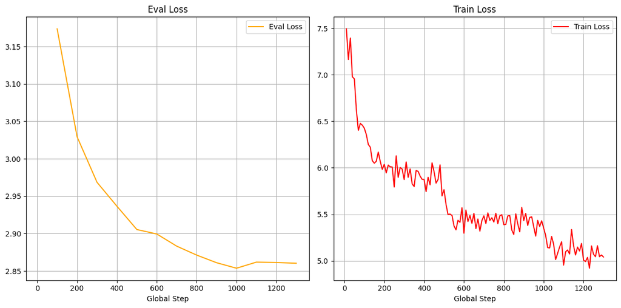

```python
plot_sft_results('i1hgcxfb')
```

**Evaluation**

```python
res_ft_130_piqa_sft = eval_model(model_130, tokenizer, ['piqa'])
print('Fine tuned: ',res_ft_130_piqa_sft['results'])
```

Mamba 130m (torch.float32) fine-tuned with SFT:

```
{'piqa': {'alias': 'piqa', 'acc,none': 0.6806311207834603, 'acc_stderr,none': 0.010877964076613867, 'acc_norm,none': 0.6605005440696409, 'acc_norm_stderr,none': 0.011048455047173906}}
```

##### float16 and bfloat16

Here we try using float16 and bfloat16 from the models (i.e., we set `torch_dtype=torch.(b)float16`).

**float16**

```python
dir_130_sft_f16 = "/content/drive/MyDrive/mamba2/piqa/130-sft/mamba-130m-piqa-sft-f16"

params_130m_piqa_sft_f16 = PersonalizedParams(
    output_dir=dir_130_sft_f16,
    num_train_epochs=3,
    eval_steps=100,
    save_steps=1,
    batch_size=16,
    gradient_accumulation_steps=2,
    warmup_ratio=0.1,
    learning_rate=5e-5,
    weight_decay=0.01,
    lr_scheduler_type='cosine'
)

params_130m_piqa_sft_f16
```

```python
trainer_130m_sft_f16 = PersonalizedTrainer(
    model = model_130,
    strategy='sft',
    params=params_130m_piqa_sft_f16,
    early_stopping_patience = 3
)

trainer_130m_sft_f16
```

```python
finetuner_130_sft_f16 = MambaFineTuner(dataset_piqa, trainer_130m_sft_f16)
finetuner_130_sft_f16.tune(dir_130_sft_f16)
```

Run id: nfs5nkqk

Run duration: 0:04:16

| Epoch | Step | Train Loss | Eval Loss |
| --- | --- | --- | --- |
| 0.1984 | 100 | 0 | nan |

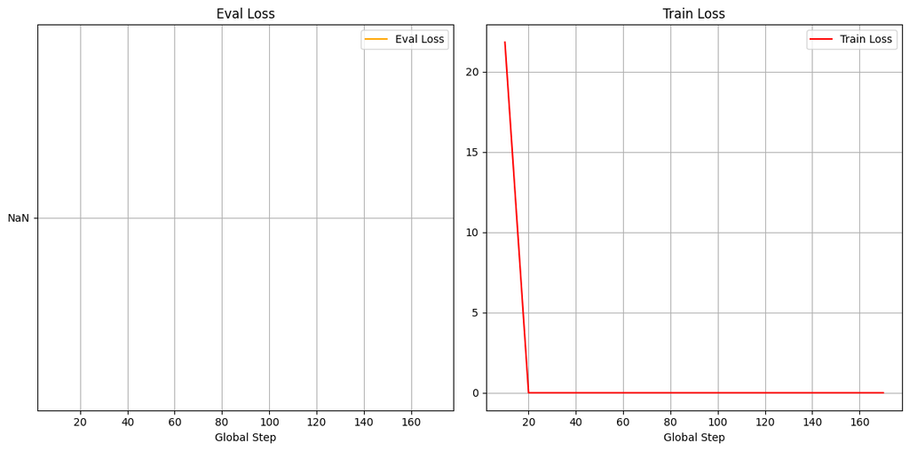

```python
plot_sft_results('nfs5nkqk')
```

**Validation**

```python
res_ft_130_sft_f16 = eval_model(model_130, tokenizer, ['piqa'])
print(f'Fine tuned ({model_130.dtype}): {res_ft_130_sft_f16["results"]}')
```

Fine tuned (float 16):

```
{'piqa': {'alias': 'piqa', 'acc,none': 0.49510337323177367, 'acc_stderr,none': 0.01166526473007814, 'acc_norm,none': 0.49510337323177367, 'acc_norm_stderr,none': 0.01166526473007814}}
```

Here we see that the model downgrade, probably it is because some compatibility issues. Moreover during the training phase logs were pretty weird, e.g. the grandients norm was always NaN and the loss function on the training dataset was always 0.

We did not investigate this results for the reasons said before.

**bfloat16**

```python
dir_130_sft_bf16 = "/content/drive/MyDrive/mamba2/mamba-piqa-130m-sft-bf16-v2"

params_130m_sft_bf16 = PersonalizedParams(
    output_dir=dir_130_sft_bf16,
    eval_steps=200,
    save_steps=3,
    batch_size=16,
)

params_130m_sft_bf16
```

```python
trainer_130m_sft_bf16 = PersonalizedTrainer(
    model = model_130,
    strategy='sft',
    params=params_130m_sft_bf16,
    early_stopping_patience = 3
)

trainer_130m_sft_bf16
```

```python
finetuner_130_sft_bf16 = MambaFineTuner(dataset_piqa, trainer_130m_sft_bf16)
finetuner_130_sft_bf16.tune(dir_130_sft_bf16)
```

Run id: 84gmz55k

Run duration: 0:42:14

| Epoch | Step | Train Loss | Eval Loss |
| --- | --- | --- | --- |
| 0.1984 | 200 | 2.929 | 2.9345 |
| 0.3968 | 400 | 2.7171 | 2.8274 |
| 0.5952 | 600 | 2.6279 | 2.7694 |
| 0.7937 | 800 | 2.7386 | 2.7333 |
| 0.9921 | 1000 | 2.737 | 2.697 |
| 1.1905 | 1200 | 2.396 | 2.6854 |
| 1.3889 | 1400 | 2.5944 | 2.664 |
| 1.5873 | 1600 | 2.5079 | 2.6528 |
| 1.7857 | 1800 | 2.5203 | 2.6412 |
| 1.9841 | 2000 | 2.5874 | 2.631 |
| 2.1825 | 2200 | 2.3553 | 2.6369 |
| 2.381 | 2400 | 2.3096 | 2.6324 |
| 2.5794 | 2600 | 2.3696 | 2.6308 |
| 2.7778 | 2800 | 2.2662 | 2.6279 |
| 2.9762 | 3000 | 2.4901 | 2.6273 |

```
Run id: 84gmz55k
```

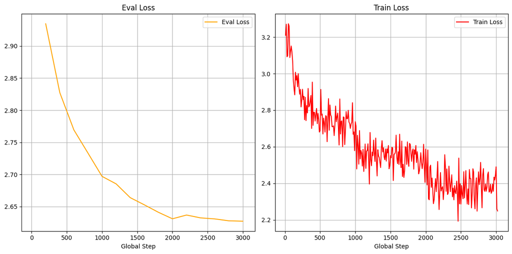

```python
plot_sft_results('84gmz55k')
```

**Evaluation**

```python
res_ft_130_sft_bf16 = eval_model(model_130, tokenizer, ['piqa'])
print('Fine tuned (bfloat 16): ',res_ft_130_sft_bf16['results'])
```

Fine tuned (bfloat 16):

```
{'piqa': {'alias': 'piqa', 'acc,none': 0.6735582154515778, 'acc_stderr,none': 0.010940467046177304, 'acc_norm,none': 0.6632208922742111, 'acc_norm_stderr,none': 0.011026738925251179}}
```

Here the results are comparable and the training does not behave weird, but with the model in `torch.float32` the results are better and we can use the mixed precision to make the training faster.

#### DPO

##### float32

```python
dir_130_dpo = "/content/drive/MyDrive/mamba2/piqa/130-dpo/mamba-130m-piqa-dpo-v8"

params_130m_dpo = PersonalizedParams(
    output_dir=dir_130_dpo,
    num_train_epochs=2,
    eval_steps=100,
    save_steps=3,
    batch_size=4,
    gradient_accumulation_steps=4,
    warmup_ratio=0.0,
    learning_rate=2e-5,
    weight_decay=0.01,
    lr_scheduler_type='cosine'
)

params_130m_dpo.set_param('fp16', True)

params_130m_dpo
```

```python
trainer_130m_dpo = PersonalizedTrainer(
    model = model_130,
    strategy='dpo',
    params=params_130m_dpo,
    early_stopping_patience = 3
)

trainer_130m_dpo
```

```python
finetuner_130_dpo = MambaFineTuner(dataset_piqa, trainer_130m_dpo)
finetuner_130_dpo.tune(dir_130_dpo)
```

Run id: i2dds9yk

Run duration: 0:30:47

| Epoch | Step | Train Loss | Eval Loss | Eval Accuracy |
| --- | --- | --- | --- | --- |
| 0.0993 | 100 | 0.6622 | 0.6479 | 0.6543 |
| 0.1986 | 200 | 0.6317 | 0.6363 | 0.669 |
| 0.2978 | 300 | 0.6554 | 0.6297 | 0.6652 |
| 0.3971 | 400 | 0.66 | 0.6178 | 0.6772 |
| 0.4964 | 500 | 0.6146 | 0.6144 | 0.6897 |
| 0.5957 | 600 | 0.5857 | 0.6094 | 0.7022 |
| 0.695 | 700 | 0.5912 | 0.6056 | 0.7043 |
| 0.7942 | 800 | 0.5645 | 0.6029 | 0.7054 |
| 0.8935 | 900 | 0.6012 | 0.6027 | 0.7174 |
| 0.9928 | 1000 | 0.5631 | 0.5987 | 0.7136 |
| 1.0913 | 1100 | 0.2956 | 0.6215 | 0.6995 |
| 1.1906 | 1200 | 0.2857 | 0.6377 | 0.6946 |
| 1.2899 | 1300 | 0.3022 | 0.6449 | 0.6935 |
| 1.3892 | 1400 | 0.2963 | 0.644 | 0.6957 |

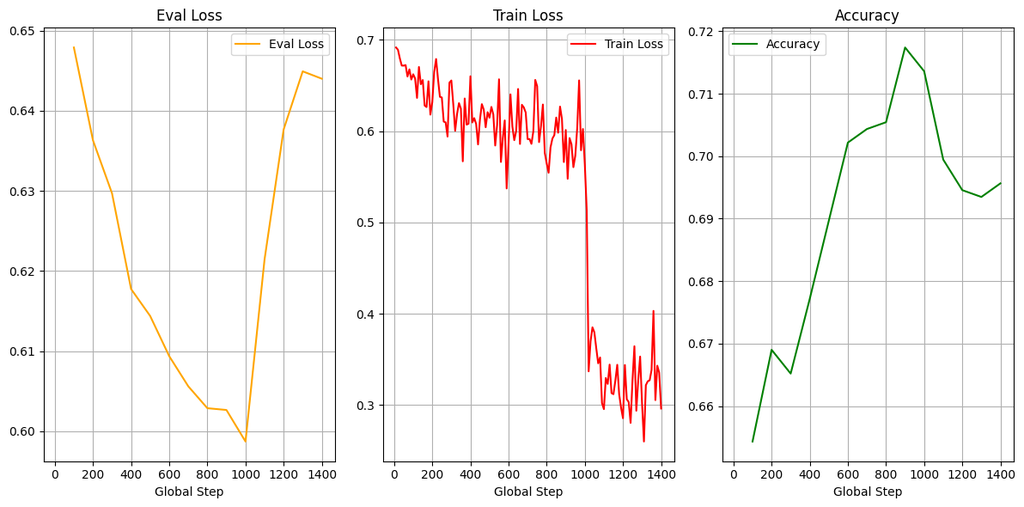

```python
plot_dpo_results('i2dds9yk')
```

**Evaluation**

```python
res_ft_130_dpo = eval_model(model_130, tokenizer, ['piqa'])
print('Fine tuned: ',res_ft_130_dpo['results'])
```

Mamba 130m (torch.float32) fine-tuned with DPO:

```
{'piqa': {'alias': 'piqa', 'acc,none': 0.6844396082698585, 'acc_stderr,none': 0.010843119201758775, 'acc_norm,none': 0.6855277475516867, 'acc_norm_stderr,none': 0.010833009065106529}}
```

##### bfloat16

Here we did not even try to use the model in `torch.float16` for the reasons said above.

We tried just the model in `torch.bfloat16` to confirm our main idea.

**bfloat16**

```python
dir_130_dpo_bf16 = "/content/drive/MyDrive/mamba2/mamba-piqa-130m-dpo-bf16-v2"

params_130m_dpo_bf16 = PersonalizedParams(
    output_dir=dir_130_dpo_bf16,
    eval_steps=1000,
    save_steps=3,
    batch_size=4,
)
params_130m_dpo_bf16.set_param('bf16', True)

params_130m_dpo_bf16
```

```python
trainer_130m_dpo_bf16 = PersonalizedTrainer(
    model = model_130,
    strategy='dpo',
    params=params_130m_dpo_bf16,
    early_stopping_patience = 3
)

trainer_130m_dpo_bf16
```

```python
finetuner_130_dpo_bf16 = MambaFineTuner(dataset_piqa, trainer_130m_dpo_bf16)
finetuner_130_dpo_bf16.tune(dir_130_dpo_bf16)
```

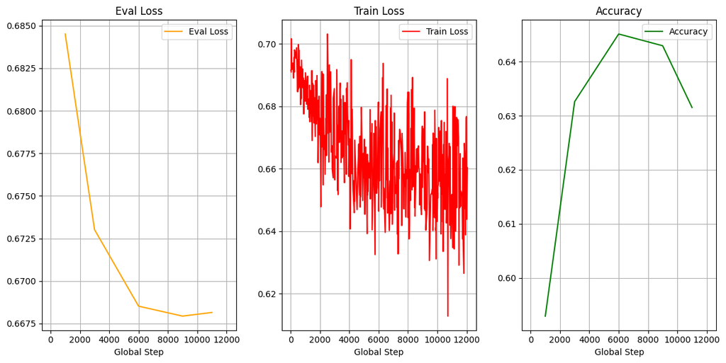

```python
id_130_dpo_bf16 = '8j7863qg'
plot_dpo_results(id_130_dpo_bf16)
```

**Evaluation**

```python
res_ft_130_sft_bf16 = eval_model(model_130, tokenizer, ['piqa'])
print('Fine tuned (bfloat 16): ',res_ft_130_sft_bf16['results'])
```

Fine tuned (bfloat 16):

[output not shown]

Same considerations as above.

### Mamba 370m

```python
res_370_piqa = eval_model(model_370, tokenizer, ['piqa'])
print(f'Results base model ({model_370.dtype}): {res_370_piqa["results"]}')
```

Results base model (torch.float32):

```
{'piqa': {'alias': 'piqa', 'acc,none': 0.6947769314472253, 'acc_stderr,none': 0.010744267045606553, 'acc_norm,none': 0.6833514689880305, 'acc_norm_stderr,none': 0.01085316053197854}}
```

As expected, they are the same as in the original paper.

#### SFT

```python
dir_370_sft = "/content/drive/MyDrive/mamba2/mamba-piqa-370m-sft-v3"

params_370m_sft = PersonalizedParams(
    output_dir=dir_370_sft,
    eval_steps=100,
    save_steps=1,
    batch_size=4,
    gradient_accumulation_steps=8,
    learning_rate=4e-5,
    weight_decay=0.05,
    warmup_ratio=0.15,
    lr_scheduler_type='cosine'
)

params_370m_sft.set_param('fp16', True)

params_370m_sft
```

```python
trainer_370m_sft = PersonalizedTrainer(
    model = model_370,
    strategy='sft',
    params=params_370m_sft,
    early_stopping_patience = 5
)

trainer_370m_sft
```

```python
finetuner_370_sft = MambaFineTuner(dataset_piqa, trainer_370m_sft)
finetuner_370_sft.tune(dir_370_sft)
```

Run id: gpuc6b0u

Run duration: 0:56:11

| Epoch | Step | Train Loss | Eval Loss |
| --- | --- | --- | --- |
| 0.1986 | 100 | 23.5649 | 2.8635 |
| 0.3971 | 200 | 22.3542 | 2.7476 |
| 0.5957 | 300 | 21.9925 | 2.7041 |
| 0.7942 | 400 | 21.5133 | 2.6745 |
| 0.9928 | 500 | 21.067 | 2.6435 |
| 1.1906 | 600 | 18.0363 | 2.671 |
| 1.3892 | 700 | 18.6284 | 2.6546 |
| 1.5877 | 800 | 18.4373 | 2.6386 |
| 1.7863 | 900 | 18.5366 | 2.627 |
| 1.9849 | 1000 | 18.0429 | 2.6172 |
| 2.1827 | 1100 | 14.6181 | 2.7198 |
| 2.3812 | 1200 | 14.8336 | 2.7205 |
| 2.5798 | 1300 | 14.9064 | 2.7167 |
| 2.7784 | 1400 | 14.9578 | 2.7194 |
| 2.9769 | 1500 | 15.3961 | 2.7186 |

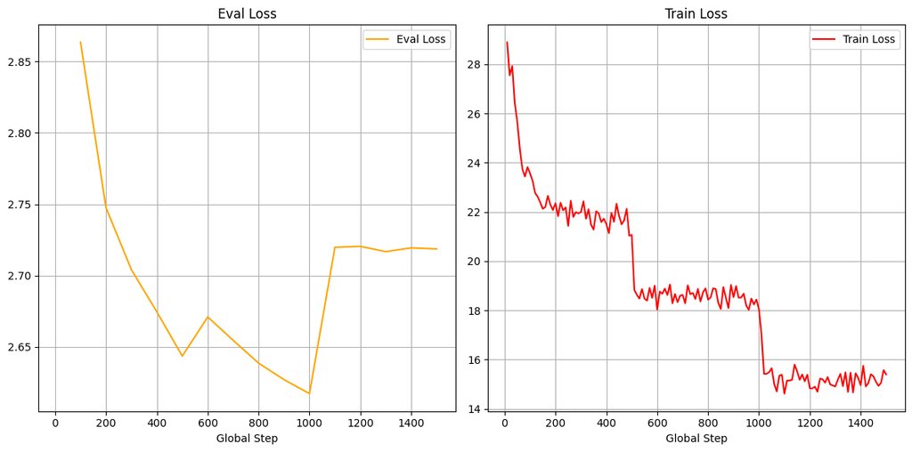

```python
plot_sft_results('gpuc6b0u')
```

**Evaluation**

```python
res_ft_370_sft = eval_model(model_370, tokenizer, ['piqa'])
print('Fine tuned: ',res_ft_370_sft['results'])
```

Mamba 370m (torch.float32) fine-tuned with SFT:

```
{'piqa': {'alias': 'piqa', 'acc,none': 0.7312295973884657, 'acc_stderr,none': 0.01034339294008991, 'acc_norm,none': 0.7383025027203483, 'acc_norm_stderr,none': 0.010255630772708123}}
```

#### DPO

```python
dir_370_dpo = "/content/drive/MyDrive/mamba2/piqa/370-dpo/mamba-370m-piqa-dpo-v4"

params_370m_dpo = PersonalizedParams(
    output_dir=dir_370_dpo,
    eval_steps=100,
    save_steps=1,
    batch_size=2,
    gradient_accumulation_steps=8,
    metric_for_best_model='rewards/accuracies',
    learning_rate=2e-5,
    weight_decay=0.01,
    warmup_ratio=0.0,
    lr_scheduler_type='cosine',
    num_train_epochs=2
)

params_370m_dpo.set_param('fp16', True)
params_370m_dpo.set_param('greater_is_better', True)

params_370m_dpo
```

```python
trainer_370m_dpo = PersonalizedTrainer(
    model = model_370,
    strategy='dpo',
    params=params_370m_dpo,
    early_stopping_patience = 3
)

trainer_370m_dpo
```

```python
finetuner_370_dpo = MambaFineTuner(dataset_piqa, trainer_370m_dpo)
finetuner_370_dpo.tune(save=dir_370_dpo)
```

Run id: cc35khm9

Run duration: 1:21:13

| Epoch | Step | Train Loss | Eval Loss | Eval Accuracy |
| --- | --- | --- | --- | --- |
| 0.0993 | 100 | 0.6644 | 0.6064 | 0.71 |
| 0.1986 | 200 | 0.6027 | 0.5924 | 0.7106 |
| 0.2979 | 300 | 0.5913 | 0.5696 | 0.7378 |
| 0.3972 | 400 | 0.5757 | 0.5615 | 0.7383 |
| 0.4965 | 500 | 0.571 | 0.5444 | 0.7557 |
| 0.5958 | 600 | 0.5069 | 0.5313 | 0.7633 |
| 0.695 | 700 | 0.5462 | 0.5304 | 0.7606 |
| 0.7943 | 800 | 0.4215 | 0.5187 | 0.7639 |
| 0.8936 | 900 | 0.5019 | 0.5235 | 0.7682 |
| 0.9929 | 1000 | 0.4519 | 0.5104 | 0.7699 |
| 1.0913 | 1100 | 0.1017 | 0.5984 | 0.7601 |
| 1.1906 | 1200 | 0.0991 | 0.6231 | 0.7606 |
| 1.2899 | 1300 | 0.1578 | 0.6271 | 0.7622 |

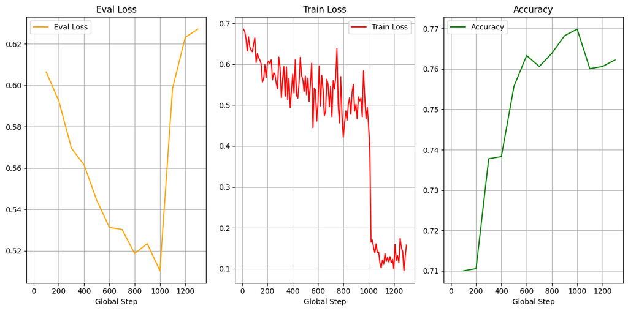

```python
plot_dpo_results('cc35khm9')
```

**Evaluation**

```python
res_ft_370_dpo = eval_model(model_370, tokenizer, ['piqa'])
print('Fine tuned: ',res_ft_370_dpo['results'])
```

Mamba 370m (torch.float32) fine-tuned with DPO:

```
{'piqa': {'alias': 'piqa', 'acc,none': 0.7616974972796517, 'acc_stderr,none': 0.009940334245876358, 'acc_norm,none': 0.763873775843308, 'acc_norm_stderr,none': 0.009908965890558312}}
```

### Mamba 790m

```python
res_790_piqa = eval_model(model_790, tokenizer, ['piqa'])
print(f'Results base model ({model_790.dtype}): {res_790_piqa["results"]}')
```

Results base model (torch.float32):

```
{'piqa': {'alias': 'piqa', 'acc,none': 0.721436343852013, 'acc_stderr,none': 0.01045939723596504, 'acc_norm,none': 0.7263329706202394, 'acc_norm_stderr,none': 0.010402184206229258}}
```

Same as the paper.

#### SFT

```python
dir_790_sft = "/content/drive/MyDrive/mamba2/790-sft/mamba-790m-piqa-sft"

params_790m_sft = PersonalizedParams(
    output_dir=dir_790_sft,
    eval_steps=200,
    save_steps=1,
    batch_size=1,
    gradient_accumulation_steps=16,
    learning_rate=4e-5,
    weight_decay=0.01,
    warmup_ratio=0.1,
    lr_scheduler_type='cosine'
)

params_790m_sft.set_param('bf16', True)

params_790m_sft
```

```python
trainer_790m_sft = PersonalizedTrainer(
    model = model_790,
    strategy='sft',
    params=params_790m_sft,
    early_stopping_patience = 3
)

trainer_790m_sft
```

```python
finetuner_790_sft = MambaFineTuner(dataset_piqa, trainer_790m_sft)
finetuner_790_sft.tune(save=dir_790_sft)
```

Run id: 4pe5wll1

Run duration: 3:47:43.283868

| Epoch | Step | Train Loss | Eval Loss |
| --- | --- | --- | --- |
| 0.1986 | 200 | 54.049 | 3.3611 |
| 0.3972 | 400 | 47.5302 | 3.0006 |
| 0.5958 | 600 | 46.6247 | 2.8909 |
| 0.7944 | 800 | 46.6755 | 2.8422 |
| 0.993 | 1000 | 44.5762 | 2.813 |
| 1.1907 | 1200 | 42.1933 | 2.7973 |
| 1.3893 | 1400 | 43.1159 | 2.7856 |
| 1.5878 | 1600 | 41.9213 | 2.7768 |
| 1.7864 | 1800 | 43.2266 | 2.7738 |
| 1.985 | 2000 | 43.8596 | 2.7702 |
| 2.1827 | 2200 | 41.8203 | 2.7685 |

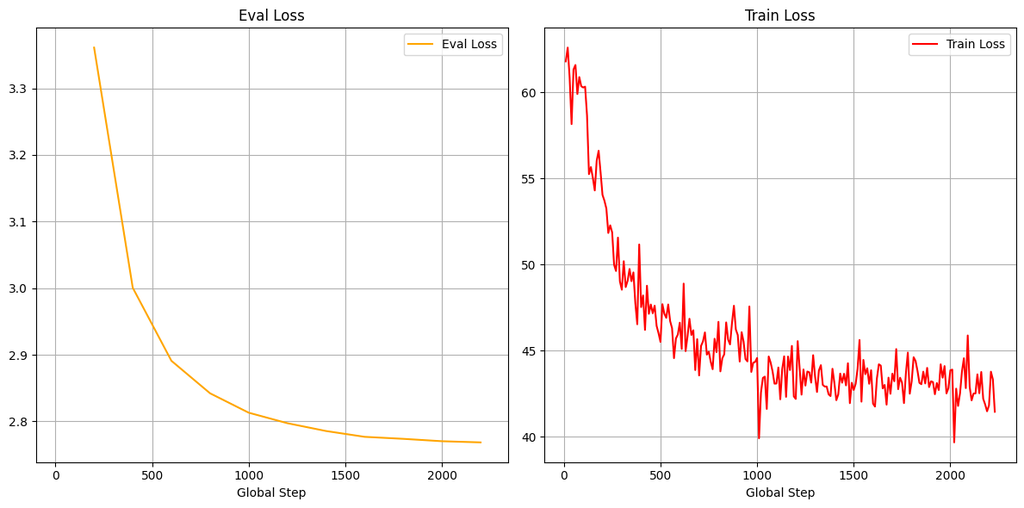

```python
plot_sft_results('4pe5wll1')
```

**Evaluation**

```python
res_ft_790_sft = eval_model(model_790, tokenizer, ['piqa'])
print('Fine tuned: ',res_ft_790_sft['results'])
```

Mamba 790m (`torch.float32`) fine-tuned with SFT:

```
Fine tuned:  {'piqa': {'alias': 'piqa', 'acc,none': 0.733949945593036, 'acc_stderr,none': 0.010310039263352765, 'acc_norm,none': 0.7377584330794341, 'acc_norm_stderr,none': 0.010262502565172393}}
```

#### DPO

```python
dir_790_dpo = "/content/drive/MyDrive/mamba2/piqa/790-dpo/mamba-790m-piqa-dpo"

params_790m_dpo = PersonalizedParams(
    output_dir=dir_790_dpo,
    eval_steps=200,
    save_steps=5,
    batch_size=2,
    gradient_accumulation_steps=8,
    metric_for_best_model='rewards/accuracies',
    learning_rate=4e-5,
    weight_decay=0.01,
    warmup_ratio=0.1,
    lr_scheduler_type='cosine',
    num_train_epochs=2
)

params_790m_dpo.set_param('bf16', True)
params_790m_dpo.set_param('bf16_full_eval', True)
params_790m_dpo.set_param('greater_is_better', True)

params_790m_dpo
```

```python
trainer_790m_dpo = PersonalizedTrainer(
    model = model_790,
    strategy='dpo',
    params=params_790m_dpo,
    early_stopping_patience = 3
)

trainer_790m_dpo
```

```python
finetuner_790_dpo = MambaFineTuner(dataset_piqa, trainer_790m_dpo)
finetuner_790_dpo.tune(save=dir_790_dpo)
```

Run id: npp92zb6

Run duration: 3:41:43

| Epoch | Step | Train Loss | Eval Loss | Eval Accuracy |
| --- | --- | --- | --- | --- |
| 0.1986 | 200 | 0.6679 | 0.6607 | 0.6703 |
| 0.3972 | 400 | 0.6452 | 0.5978 | 0.7155 |
| 0.5958 | 600 | 0.5669 | 0.569 | 0.7383 |
| 0.7943 | 800 | 0.5441 | 0.5479 | 0.7492 |
| 0.9929 | 1000 | 0.5579 | 0.5373 | 0.7612 |
| 1.1906 | 1200 | 0.3501 | 0.5324 | 0.759 |
| 1.3892 | 1400 | 0.4017 | 0.533 | 0.7573 |

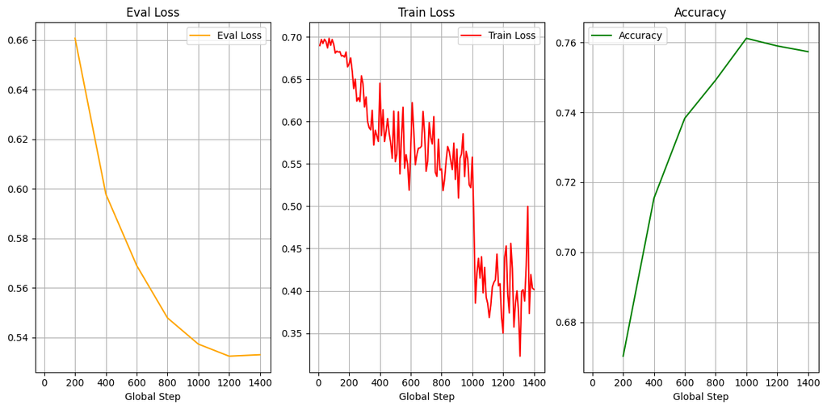

```python
plot_dpo_results('npp92zb6')
```

**Evaluation**

```python
model_790 = AutoModelForCausalLM.from_pretrained(dir_790_dpo+'/checkpoint-1000')
model_790.to(device)
```

```
MambaForCausalLM(
  (backbone): MambaModel(
    (embeddings): Embedding(50280, 1536)
    (layers): ModuleList(
      (0-47): 48 x MambaBlock(
        (norm): MambaRMSNorm(1536, eps=1e-05)
        (mixer): MambaMixer(
          (conv1d): Conv1d(3072, 3072, kernel_size=(4,), stride=(1,), padding=(3,), groups=3072)
          (act): SiLU()
          (in_proj): Linear(in_features=1536, out_features=6144, bias=False)
          (x_proj): Linear(in_features=3072, out_features=128, bias=False)
          (dt_proj): Linear(in_features=96, out_features=3072, bias=True)
          (out_proj): Linear(in_features=3072, out_features=1536, bias=False)
        )
      )
    )
    (norm_f): MambaRMSNorm(1536, eps=1e-05)
  )
  (lm_head): Linear(in_features=1536, out_features=50280, bias=False)
)
```

```python
res_ft_790_dpo = eval_model(model_790, tokenizer, ['piqa'])
print('Fine tuned: ',res_ft_790_dpo['results'])
```

Mamba 790m (`torch.bfloat16`) fine-tuned with DPO:

```
Fine tuned:  {'piqa': {'alias': 'piqa', 'acc,none': 0.7535364526659413, 'acc_stderr,none': 0.01005481078967165, 'acc_norm,none': 0.750816104461371, 'acc_norm_stderr,none': 0.010091882770120146}}
```

## PIQA - LoRA

- We experimented with **Low-Rank Adaptation (LoRA)** to investigate whether this parameter-efficient fine-tuning technique could improve results.
- Standard fine-tuning updates all weights of a pre-trained model.
  - **Downside:** the fine-tuned model contains as many parameters as the base model, leading to high computational and memory costs.
- LoRA introduces a **low-rank decomposition approach**:
  - Instead of modifying the full weight matrix, LoRA trains two smaller *update matrices* (low-rank factors).
  - The original pre-trained weights remain **frozen**, while the smaller matrices are optimized.
  - At inference, the adapted weights are merged with the frozen weights to generate the final outputs.
- **Advantages of LoRA:**
  - **Parameter efficiency**, drastically reduces trainable parameters, lowering training cost.
  - **Modularity**, adapters can be trained for different downstream tasks while keeping the same base model.
  - **Compatibility**, orthogonal to other parameter-efficient fine-tuning methods.
  - **Performance**, achieves accuracy comparable to full fine-tuning.
  - **No inference latency**, adapter weights can be merged into the base model, avoiding runtime overhead.

[figure not shown]

Image from 14.

- In practice:
  - LoRA can be applied selectively to chosen weight matrices within the network.
  - The number of trainable parameters depends on the **rank $r$** of the update matrices relative to the original weight matrix.
  - While separate LoRA adapters are lightweight, maintaining them independently may introduce inference latency.
  - **Solution:** merge the LoRA weights with the base model. Since the two low-rank matrices ($A$ and $B$) recombine into a full matrix equivalent to the updated weights, the merged model becomes a standalone version without extra overhead.

*PEFT Setup*

- We applied **Low-Rank Adaptation (LoRA)** to all selected Mamba models (130M, 370M, 790M, and 1.4B parameters).
- Each model was fine-tuned on the **PIQA dataset** under both SFT and DPO settings.
- To ensure comparability, we used a fixed **LoRA configuration** defined with Hugging Face’s `peft` library:
  - `rank_dimension = 16`
    - Controls the size of the low-rank decomposition.
    - Smaller rank, fewer trainable parameters, more efficiency, but reduced expressive capacity.
  - `lora_alpha = 32`
    - Scaling factor for the LoRA updates relative to frozen base weights.
    - Stabilizes training by preventing updates from being too weak or overly dominant.
  - `lora_dropout = 0.1`
    - Dropout probability (10%) applied to LoRA updates.
    - Helps regularize training and reduce overfitting.
  - `target_modules = ["x_proj", "dt_proj", "in_proj", "embeddings"]`
    - Modules suggested by Hugging Face documentation for Mamba models.
    - Excludes `out_proj`, which is not supported by LoRA.
  - `task_type = "CAUSAL_LM"`
    - Specifies causal language modeling as the downstream task.
- This configuration (referred to as `peft_config`) strikes a balance between **parameter efficiency** and **performance**, while enabling systematic comparison across model scales and training strategies.

```python
from peft import LoraConfig

rank_dimension = 16
lora_alpha = 32
lora_dropout = 0.1

peft_config = LoraConfig(
    r=rank_dimension,
    lora_alpha=lora_alpha,
    lora_dropout=lora_dropout,
    bias="none",
    target_modules=["x_proj", "dt_proj", "in_proj", "embeddings"],
    task_type="CAUSAL_LM",
)
```

### 130m

#### SFT

```python
dir_130_piqa_sft = "/content/drive/MyDrive/mamba2/piqa/lora/mamba-130m-piqa-sft-lora-v4"

params_130m_piqa_sft = PersonalizedParams(
    output_dir=dir_130_piqa_sft,
    num_train_epochs=3,
    eval_steps=100,
    save_steps=3,
    batch_size=16,
    gradient_accumulation_steps=2,
    warmup_ratio=0.1,
    learning_rate=4e-5,
    weight_decay=0.005,
)

params_130m_piqa_sft.set_param('fp16', True)

params_130m_piqa_sft
```

```python
trainer_130m_piqa_sft = PersonalizedTrainer(
    model = model_130,
    strategy='sft',
    params=params_130m_piqa_sft,
    early_stopping_patience = 5,
    peft_config=peft_config
)

trainer_130m_piqa_sft
```

```python
finetuner_130_piqa_sft = MambaFineTuner(dataset_piqa, trainer_130m_piqa_sft)
finetuner_130_piqa_sft.tune(dir_130_piqa_sft)
```

Run id: ojw9e0gl

Run duration: 0:24:19

| Epoch | Step | Train Loss | Eval Loss |
| --- | --- | --- | --- |
| 0.1984 | 100 | 7.3099 | 3.6427 |
| 0.3968 | 200 | 6.5652 | 3.2877 |
| 0.5952 | 300 | 6.2375 | 3.1893 |
| 0.7937 | 400 | 6.2775 | 3.1449 |
| 0.9921 | 500 | 6.122 | 3.1178 |
| 1.1905 | 600 | 5.9526 | 3.0989 |
| 1.3889 | 700 | 6.0939 | 3.085 |
| 1.5873 | 800 | 6.0016 | 3.0752 |
| 1.7857 | 900 | 6.0719 | 3.0665 |
| 1.9841 | 1000 | 5.9793 | 3.0603 |
| 2.1825 | 1100 | 5.8306 | 3.0555 |
| 2.381 | 1200 | 5.9137 | 3.0523 |
| 2.5794 | 1300 | 5.9013 | 3.0499 |
| 2.7778 | 1400 | 5.965 | 3.0484 |
| 2.9762 | 1500 | 6.1359 | 3.0477 |

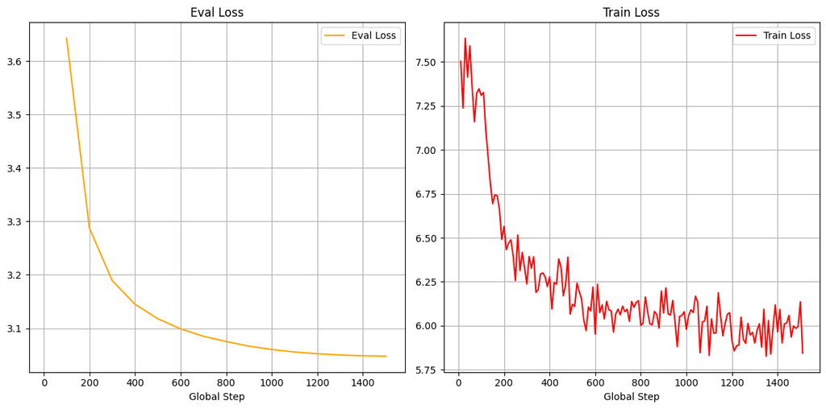

```python
plot_sft_results('ojw9e0gl')
```

```python
res_ft_130_piqa_sft = eval_model(model_130, tokenizer, ['piqa'])
print('Fine tuned: ',res_ft_130_piqa_sft['results'])
```

Mamba 130m fine-tuned with LoRA and SFT:

```
{'piqa': {'alias': 'piqa', 'acc,none': 0.6507072905331882, 'acc_stderr,none': 0.011123283817525193, 'acc_norm,none': 0.6436343852013058, 'acc_norm_stderr,none': 0.01117410986586477}}
```

#### DPO

```python
dir_130_piqa_dpo = "/content/drive/MyDrive/mamba2/piqa/lora/mamba-130m-piqa-dpo-lora"

params_130m_piqa_dpo = PersonalizedParams(
    output_dir=dir_130_piqa_dpo,
    num_train_epochs=2,
    eval_steps=100,
    save_steps=3,
    batch_size=4,
    gradient_accumulation_steps=4,
    warmup_ratio=0.0,
    learning_rate=2e-5,
    weight_decay=0.01,
    lr_scheduler_type='cosine'
)

params_130m_piqa_dpo.set_param('fp16', True)

params_130m_piqa_dpo
```

```python
trainer_130m_piqa_dpo = PersonalizedTrainer(
    model = model_130,
    strategy='dpo',
    params=params_130m_piqa_dpo,
    early_stopping_patience = 5,
    peft_config=peft_config
)

trainer_130m_piqa_dpo
```

```python
finetuner_130_piqa_dpo = MambaFineTuner(dataset_piqa, trainer_130m_piqa_dpo)
finetuner_130_piqa_dpo.tune(dir_130_piqa_dpo)
```

Run id: 0zyrmcvm

Run duration: 0:47:51

| Epoch | Step | Train Loss | Eval Loss | Eval Accuracy |
| --- | --- | --- | --- | --- |
| 0.0993 | 100 | 0.6915 | 0.691 | 0.6228 |
| 0.1986 | 200 | 0.6861 | 0.6872 | 0.6467 |
| 0.2978 | 300 | 0.6828 | 0.68 | 0.6397 |
| 0.3971 | 400 | 0.6771 | 0.6715 | 0.6457 |
| 0.4964 | 500 | 0.6658 | 0.661 | 0.6511 |
| 0.5957 | 600 | 0.6558 | 0.654 | 0.6489 |
| 0.695 | 700 | 0.6512 | 0.6498 | 0.6462 |
| 0.7942 | 800 | 0.6364 | 0.6474 | 0.6543 |
| 0.8935 | 900 | 0.6413 | 0.6455 | 0.6533 |
| 0.9928 | 1000 | 0.6258 | 0.6444 | 0.6549 |
| 1.0913 | 1100 | 0.5961 | 0.6435 | 0.6538 |
| 1.1906 | 1200 | 0.589 | 0.6431 | 0.6543 |
| 1.2899 | 1300 | 0.5917 | 0.6431 | 0.6527 |
| 1.3892 | 1400 | 0.6082 | 0.6429 | 0.6543 |
| 1.4885 | 1500 | 0.6447 | 0.6426 | 0.6543 |
| 1.5877 | 1600 | 0.6429 | 0.6425 | 0.6554 |
| 1.687 | 1700 | 0.5771 | 0.6424 | 0.6565 |
| 1.7863 | 1800 | 0.6183 | 0.6423 | 0.6554 |
| 1.8856 | 1900 | 0.601 | 0.6425 | 0.6549 |
| 1.9849 | 2000 | 0.629 | 0.6423 | 0.6571 |

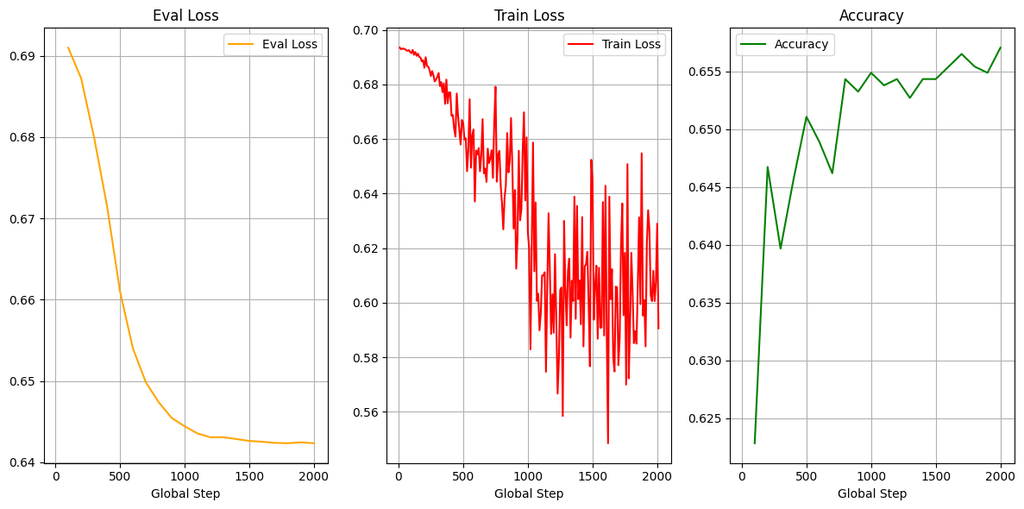

```python
plot_dpo_results('0zyrmcvm')
```

```python
res_ft_130_piqa_sft = eval_model(model_130, tokenizer, ['piqa'])
print('Fine tuned: ',res_ft_130_piqa_sft['results'])
```

Mamba 130m fine-tuned with LoRA and DPO:

```
{'piqa': {'alias': 'piqa', 'acc,none': 0.6556039173014145, 'acc_stderr,none': 0.011086521237125654, 'acc_norm,none': 0.6637649619151251, 'acc_norm_stderr,none': 0.01102234670897027}}
```

### 370m

#### SFT

```python
dir_370_sft = "/content/drive/MyDrive/mamba2/piqa/lora/mamba-370m-piqa-sft-lora"

params_370m_sft = PersonalizedParams(
    output_dir=dir_370_sft,
    eval_steps=100,
    save_steps=2,
    batch_size=4,
    gradient_accumulation_steps=8,
    learning_rate=5e-5,
    weight_decay=0.01,
    warmup_ratio=0.1,
    lr_scheduler_type='cosine',
    num_train_epochs=3
)

params_370m_sft.set_param('fp16', True)

params_370m_sft
```

```python
trainer_370m_sft = PersonalizedTrainer(
    model = model_370,
    strategy='sft',
    params=params_370m_sft,
    early_stopping_patience = 5,
    peft_config=peft_config
)

trainer_370m_sft
```

```python
finetuner_370_sft = MambaFineTuner(dataset_piqa, trainer_370m_sft)
finetuner_370_sft.tune(dir_370_sft)
```

Run id: qfvu6gbc

Run duration: 0:55:41

| Epoch | Step | Train Loss | Eval Loss |
| --- | --- | --- | --- |
| 0.1986 | 100 | 27.7763 | 3.4065 |
| 0.3971 | 200 | 24.1155 | 2.9898 |
| 0.5957 | 300 | 23.1279 | 2.8881 |
| 0.7942 | 400 | 22.7005 | 2.8484 |
| 0.9928 | 500 | 22.1553 | 2.8265 |
| 1.1906 | 600 | 21.7459 | 2.81 |
| 1.3892 | 700 | 22.146 | 2.7971 |
| 1.5877 | 800 | 21.9754 | 2.788 |
| 1.7863 | 900 | 22.1186 | 2.781 |
| 1.9849 | 1000 | 21.7251 | 2.7766 |
| 2.1827 | 1100 | 21.243 | 2.7734 |
| 2.3812 | 1200 | 21.6281 | 2.7711 |
| 2.5798 | 1300 | 21.6626 | 2.7699 |
| 2.7784 | 1400 | 21.7202 | 2.7695 |
| 2.9769 | 1500 | 22.4553 | 2.7694 |

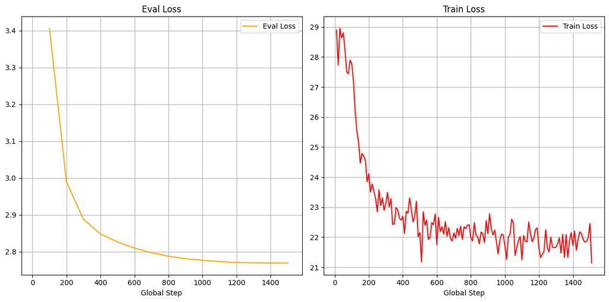

```python
plot_sft_results('qfvu6gbc')
```

**Evaluation**

```python
res_ft_370_sft = eval_model(model_370, tokenizer, ['piqa'])
print('Fine tuned: ',res_ft_370_sft['results'])
```

Mamba 370m fine-tuned with LoRA and SFT:

```
Fine tuned:  {'piqa': {'alias': 'piqa', 'acc,none': 0.7072905331882481, 'acc_stderr,none': 0.010616044462393127, 'acc_norm,none': 0.7040261153427638, 'acc_norm_stderr,none': 0.01065041431714814}}
```

#### DPO

```python
dir_370_dpo = "/content/drive/MyDrive/mamba2/piqa/lora/mamba-370m-piqa-dpo-lora-v2"

params_370m_dpo = PersonalizedParams(
    output_dir=dir_370_dpo,
    eval_steps=200,
    save_steps=2,
    batch_size=2,
    gradient_accumulation_steps=8,
    metric_for_best_model='rewards/accuracies',
    learning_rate=2e-5,
    weight_decay=0.01,
    warmup_ratio=0.0,
    lr_scheduler_type='cosine',
    num_train_epochs=2
)

params_370m_dpo.set_param('fp16', True)
params_370m_dpo.set_param('greater_is_better', True)

params_370m_dpo
```

```python
trainer_370m_dpo = PersonalizedTrainer(
    model = model_370,
    strategy='dpo',
    params=params_370m_dpo,
    early_stopping_patience = 3,
    peft_config=peft_config
)

trainer_370m_dpo
```

```python
finetuner_370_dpo = MambaFineTuner(dataset_piqa, trainer_370m_dpo)
finetuner_370_dpo.tune(dir_370_dpo)
```

Run id: poi0skn6

Run duration: 1:42:39

| Epoch | Step | Train Loss | Eval Loss | Eval Accuracy |
| --- | --- | --- | --- | --- |
| 0.1986 | 200 | 0.6805 | 0.6795 | 0.6746 |
| 0.3972 | 400 | 0.6421 | 0.6437 | 0.6872 |
| 0.5958 | 600 | 0.617 | 0.6193 | 0.698 |
| 0.7943 | 800 | 0.599 | 0.6103 | 0.698 |
| 0.9929 | 1000 | 0.5862 | 0.605 | 0.7008 |
| 1.1906 | 1200 | 0.5353 | 0.6029 | 0.7024 |
| 1.3892 | 1400 | 0.5341 | 0.6009 | 0.7046 |
| 1.5878 | 1600 | 0.5711 | 0.6003 | 0.7024 |
| 1.7864 | 1800 | 0.5426 | 0.6001 | 0.7024 |
| 1.985 | 2000 | 0.5762 | 0.6 | 0.7018 |

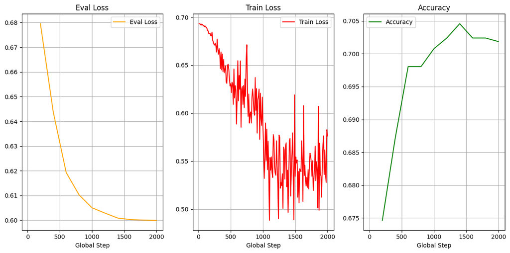

```python
plot_dpo_results('poi0skn6')
```

**Evaluation**

```python
res_ft_370_dpo = eval_model(model_370, tokenizer, ['piqa'])
print('Fine tuned: ',res_ft_370_dpo['results'])
```

Mamba 370m fine-tuned with DPO and LoRA:

```
{'piqa': {'alias': 'piqa', 'acc,none': 0.70620239390642, 'acc_stderr,none': 0.010627574080514925, 'acc_norm,none': 0.7029379760609358, 'acc_norm_stderr,none': 0.010661725404814675}}
```

### 790m

#### SFT

```python
dir_790_sft = "/content/drive/MyDrive/mamba2/piqa/lora/mamba-790m-piqa-sft-lora-v3"

params_790m_sft = PersonalizedParams(
    output_dir=dir_790_sft,
    eval_steps=100,
    batch_size=4,
    gradient_accumulation_steps=8,
    learning_rate=5e-5,
    weight_decay=0.01,
    warmup_ratio=0.1,
    lr_scheduler_type='cosine',
    num_train_epochs=3
)

params_790m_sft.set_param('fp16', True)

params_790m_sft
```

```python
trainer_790m_sft = PersonalizedTrainer(
    model = model_790,
    strategy='sft',
    params=params_790m_sft,
    early_stopping_patience = 5,
    peft_config=peft_config
)

trainer_790m_sft
```

```python
finetuner_790_sft = MambaFineTuner(dataset_piqa, trainer_790m_sft)
finetuner_790_sft.tune(dir_790_sft)
```

Run id: h2by6k9q

Run duration: 1:15:54

| Epoch | Step | Train Loss | Eval Loss |
| --- | --- | --- | --- |
| 0.1986 | 100 | 26.4525 | 3.2429 |
| 0.3971 | 200 | 22.6688 | 2.7958 |
| 0.5957 | 300 | 21.5779 | 2.7074 |
| 0.7942 | 400 | 21.3086 | 2.6722 |
| 0.9928 | 500 | 20.8143 | 2.6513 |
| 1.1906 | 600 | 20.3006 | 2.6369 |
| 1.3892 | 700 | 20.5666 | 2.6268 |
| 1.5877 | 800 | 20.479 | 2.6191 |
| 1.7863 | 900 | 20.593 | 2.6135 |
| 1.9849 | 1000 | 20.2963 | 2.6094 |
| 2.1827 | 1100 | 19.7023 | 2.6075 |
| 2.3812 | 1200 | 20.0796 | 2.6059 |
| 2.5798 | 1300 | 20.0591 | 2.6048 |
| 2.7784 | 1400 | 20.108 | 2.6046 |
| 2.9769 | 1500 | 20.7768 | 2.6044 |

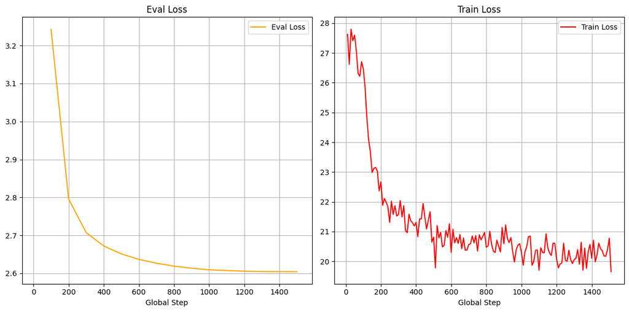

```python
plot_sft_results('h2by6k9q')
```

**Evaluation**

```python
res_ft_790_sft = eval_model(model_790, tokenizer, ['piqa'])
print('Fine tuned: ',res_ft_790_sft['results'])
```

Mamba 790m fine-tuned with LoRA and SFT:

```
{'piqa': {'alias': 'piqa', 'acc,none': 0.733949945593036, 'acc_stderr,none': 0.010310039263352765, 'acc_norm,none': 0.73449401523395, 'acc_norm_stderr,none': 0.01030330865302444}}
```

#### DPO

```python
dir_790_dpo = "/content/drive/MyDrive/mamba2/piqa/lora/mamba-790m-piqa-dpo-lora"

params_790m_dpo = PersonalizedParams(
    output_dir=dir_790_dpo,
    eval_steps=200,
    batch_size=2,
    gradient_accumulation_steps=8,
    metric_for_best_model='rewards/accuracies',
    learning_rate=5e-5,
    weight_decay=0.01,
    warmup_ratio=0.1,
    lr_scheduler_type='cosine',
    num_train_epochs=3
)

params_790m_dpo.set_param('fp16', True)

params_790m_dpo
```

```python
trainer_790m_dpo = PersonalizedTrainer(
    model = model_790,
    strategy='dpo',
    params=params_790m_dpo,
    early_stopping_patience = 5,
    peft_config=peft_config
)

trainer_790m_dpo
```

```python
finetuner_790_dpo = MambaFineTuner(dataset_piqa, trainer_790m_dpo)
finetuner_790_dpo.tune(dir_790_dpo)
```

Run id: zz098aem

Run duration: 3:28:58

| Epoch | Step | Train Loss | Eval Loss |
| --- | --- | --- | --- |
| 0.1986 | 200 | 0.6766 | 0.6731 |
| 0.3972 | 400 | 0.5872 | 0.5746 |
| 0.5958 | 600 | 0.5185 | 0.5441 |
| 0.7943 | 800 | 0.4855 | 0.5191 |
| 0.9929 | 1000 | 0.5022 | 0.5083 |
| 1.1906 | 1200 | 0.275 | 0.5296 |
| 1.3892 | 1400 | 0.3343 | 0.532 |
| 1.5878 | 1600 | 0.2883 | 0.5363 |
| 1.7864 | 1800 | 0.388 | 0.5381 |
| 1.985 | 2000 | 0.334 | 0.5208 |
| 2.1827 | 2200 | 0.2019 | 0.5743 |
| 2.3813 | 2400 | 0.1822 | 0.585 |
| 2.5799 | 2600 | 0.1808 | 0.5837 |
| 2.7785 | 2800 | 0.2028 | 0.5836 |
| 2.977 | 3000 | 0.1465 | 0.5835 |

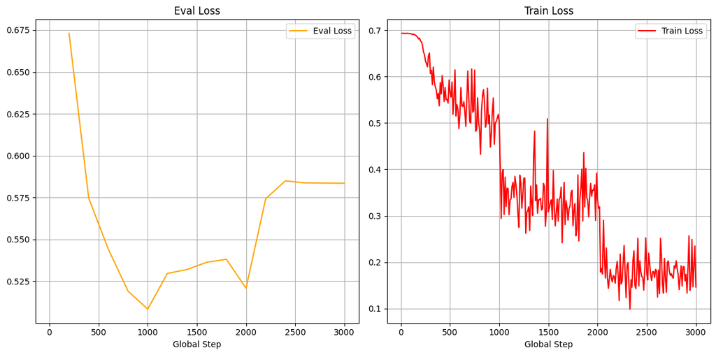

```python
plot_sft_results('zz098aem')
```

**Evaluation**

```python
res_ft_790_sft = eval_model(model_790, tokenizer, ['piqa'])
print('Fine tuned: ',res_ft_790_sft['results'])
```

Mamba 790m fine-tuned with LoRA and DPO:

```
{'piqa': {'alias': 'piqa', 'acc,none': 0.7557127312295974, 'acc_stderr,none': 0.010024765172284315, 'acc_norm,none': 0.7698585418933623, 'acc_norm_stderr,none': 0.009820832826839678}}
```

### 1.4b sft

```python
dir_1400_sft_lora = "/content/drive/MyDrive/mamba2/piqa/lora/mamba-1.4b-piqa-sft-lora"

params_1400m_sft_lora = PersonalizedParams(
    output_dir=dir_1400_sft_lora,
    eval_steps=50,
    save_steps=2,
    batch_size=4,
    gradient_accumulation_steps=16,
    num_train_epochs=3
)
params_1400m_sft_lora.set_param('fp16', True)

params_1400m_sft_lora
```

```python
trainer_1400m_sft_lora = PersonalizedTrainer(
    model = model_1400,
    strategy='sft',
    params=params_1400m_sft_lora,
    early_stopping_patience = 5,
    peft_config = peft_config
)
```

```python
res_1400_ft_sft_lora = eval_model(model_1400, tokenizer, ['piqa'])
print('Fine tuned:', res_1400_ft_sft_lora['results'])
```

Mamba 1.4b fine-tuned with LoRA and SFT:

```
{'piqa': {'alias': 'piqa', 'acc,none': 0.7459194776931447, 'acc_stderr,none': 0.010157271999135166, 'acc_norm,none': 0.7464635473340587, 'acc_norm_stderr,none': 0.010150090834551817}}
```

## ARC-E

### 130m

```python
res_130_arc_e = eval_model(model_130, tokenizer, ['arc_easy'])
print(f'Results base model ({model_130.dtype}): {res_130_arc_e["results"]}')
```

Results base model (torch.float32):

```
{'arc_easy': {'alias': 'arc_easy', 'acc,none': 0.4797979797979798, 'acc_stderr,none': 0.010251405621305271, 'acc_norm,none': 0.41919191919191917, 'acc_norm_stderr,none': 0.010124905282491126}}
```

```python
# specifica la directory in base alla strategia di training
dir_130_arce = "/content/drive/MyDrive/mamba2/arce/mamba-130m-arce-sft-text-V2"
```

#### DPO

```python
params_130m_dpo = PersonalizedParams(
    output_dir=dir_130_arce,
    eval_steps=40,
    save_steps=3,
    batch_size=16,
)

params_130m_dpo
```

```python
trainer_130m_dpo = PersonalizedTrainer(
    model = model_130,
    strategy='dpo',
    params=params_130m_dpo,
    early_stopping_patience = 3
)

trainer_130m_dpo
```

```python
finetuner_130_dpo = MambaFineTuner(dataset_arc_e, trainer_130m_dpo)
finetuner_130_dpo.tune(dir_130_arce)
```

Run id: hy7kx3qm

Run duration: 0:10:13

| Epoch | Step | Train Loss | Eval Loss |
| --- | --- | --- | --- |
| 0.2837 | 40 | 0.6595 | 0.6618 |
| 0.5674 | 80 | 0.6297 | 0.6266 |
| 0.8511 | 120 | 0.6066 | 0.5968 |
| 1.1348 | 160 | 0.2308 | 0.5766 |
| 1.4184 | 200 | 0.2515 | 0.5909 |
| 1.7021 | 240 | 0.2576 | 0.6009 |
| 1.9858 | 280 | 0.183 | 0.585 |

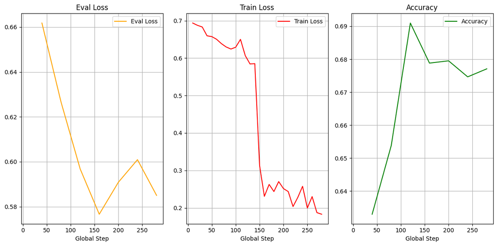

```python
plot_dpo_results('hy7kx3qm')
```

**Evaluation**

```python
model_ft_130_sft = AutoModelForCausalLM.from_pretrained(dir_130_arce)
model_ft_130_sft.to(device)
```

```python
res_ft_130_dpo = eval_model(model_130, tokenizer, ['arc_easy'])
print('Fine tuned: ',res_ft_130_dpo['results'])
```

Mamba 130m fine-tuned with DPO:

```
{{'arc_easy': {'alias': 'arc_easy', 'acc,none': 0.5542929292929293, 'acc_stderr,none': 0.010199118183322836, 'acc_norm,none': 0.5012626262626263, 'acc_norm_stderr,none': 0.010259750807990999}}
}
```

#### SFT with grid search

```python
# parameters to search
scheduler_params_search =['linear', 'cosine']
learning_rate_search= [2e-05, 3e-05, 4e-05]
weight_decay_search = [0.01, 0.05]
warmup_ratio_search = [0, 0.1, 0.2]
```

```python
v = 0
sched = scheduler_params_search[0]
for lr in learning_rate_search:
  for wd in weight_decay_search:
    for wr in warmup_ratio_search:


      v += 1
      dir_130_arce_v = dir_130_arce + '-v' + str(v)

      params_130m_sft = PersonalizedParams(
          output_dir=dir_130_arce_v,
          eval_steps=50,
          batch_size=16,
          load_best_model_at_end = False,
          save_strategy = 'no',
          learning_rate = lr,
          weight_decay = wd,
          warmup_ratio = wr,
          lr_scheduler_type= sched
          )

      params_130m_sft.set_param('fp16', True)
      params_130m_sft.set_param('save_safetensors', False)


      trainer_130m_sft = PersonalizedTrainer(
          model = AutoModelForCausalLM.from_pretrained("state-spaces/mamba-130m-hf", torch_dtype=torch.float32),
          strategy='sft',
          params=params_130m_sft,
          early_stopping_patience = 5
          )

      finetuner_130_sft = MambaFineTuner(dataset_arc_e, trainer_130m_sft)
      finetuner_130_sft.tune(dir_130_arce_v)
```

```python
v = 0
sched = scheduler_params_search[0]
for lr in learning_rate_search:
  for wd in weight_decay_search:
    for wr in warmup_ratio_search:
      v+=1
      dir_checkpoint_130_sft = dir_130_arce + '-v' + str(v)
      model_ft_130_sft = AutoModelForCausalLM.from_pretrained(dir_checkpoint_130_sft)
      model_ft_130_sft.to(device)
      res_ft_130_sft = eval_model(model_ft_130_sft, tokenizer, ['arc_easy'])
      print(f"v: {v}, lr: {lr}, wd: {wd}, wr: {wr}, res: {res_ft_130_sft['results']}")
```

[output not shown]

Worst setting:

Accuracy = 51,17%

Best setting:

- Scheduler_params = linear
- Learning_rate =4e-05
- Voce weight_decay = 0.01
- Warmup_ratio = 0.2

Accuracy = 52,14%

### 370m

```python
res_370_arc_e = eval_model(model_370, tokenizer, ['arc_easy'])
print(f'Risultati modello base ({model_370.dtype}): {res_370_arc_e["results"]}')
```

Results base model (torch.float32):

```
{'arc_easy': {'alias': 'arc_easy', 'acc,none': 0.5496632996632996, 'acc_stderr,none': 0.010209047724374136, 'acc_norm,none': 0.4819023569023569, 'acc_norm_stderr,none': 0.010253060653479045}}
```

```python
# specifica la directory in base alla strategia di training
dir_370_arce = "/content/drive/MyDrive/mamba2/arce/mamba-370m-arce-dpo-v3"
```

#### SFT

```python
params_370m_sft = PersonalizedParams(
    output_dir=dir_370_arce,
    eval_steps=80,
    save_steps=2,
    batch_size=4,
    gradient_accumulation_steps=2
)

params_370m_sft
```

```python
trainer_370m_sft = PersonalizedTrainer(
    model = model_370,
    strategy='sft',
    params=params_370m_sft,
    early_stopping_patience = 3
)

trainer_370m_sft
```

```python
finetuner_370_sft = MambaFineTuner(dataset_arc_e, trainer_370m_sft)
finetuner_370_sft.tune(dir_370_arce)
```

Run id: 5ogryn61

Run duration: 0:14:03

| Epoch | Step | Train Loss | Eval Loss |
| --- | --- | --- | --- |
| 0.2842 | 80 | 4.913 | 2.5875 |
| 0.5684 | 160 | 5.0187 | 2.506 |
| 0.8526 | 240 | 4.8491 | 2.4709 |
| 1.135 | 320 | 3.4722 | 2.5197 |
| 1.4192 | 400 | 3.5176 | 2.5304 |
| 1.7034 | 480 | 3.436 | 2.5432 |

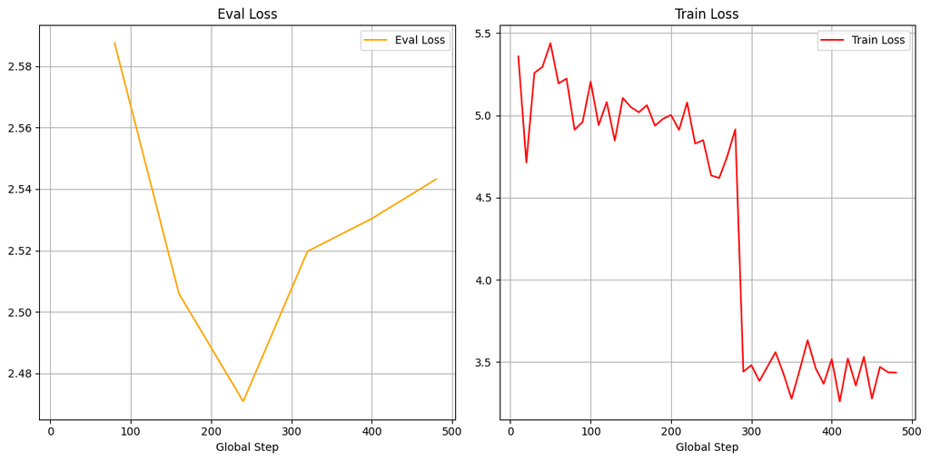

```python
plot_sft_results('5ogryn61')
```

**Evaluation**

```python
res_ft_370_sft = eval_model(model_370, tokenizer, ['arc_easy'])
print('Fine tuned: ',res_ft_370_sft['results'])
```

Mamba 370m fine-tuned with SFT:

```
{'arc_easy': {'alias': 'arc_easy', 'acc,none': 0.5904882154882155, 'acc_stderr,none': 0.010090368160989927, 'acc_norm,none': 0.5681818181818182, 'acc_norm_stderr,none': 0.010163945352271771}}}
```

#### DPO

```python
params_370m_dpo = PersonalizedParams(
    output_dir=dir_370_arce,
    eval_steps=200,
    save_steps=2,
    batch_size=2,
    gradient_accumulation_steps=4,
    learning_rate=5e-05,
    weight_decay=0.01,
    warmup_ratio=0.05,
    lr_scheduler_type = 'cosine',

)

params_370m_dpo
```

```python
trainer_370m_dpo = PersonalizedTrainer(
    model = model_370,
    strategy='dpo',
    params=params_370m_dpo,
    early_stopping_patience = 3
)

trainer_370m_dpo
```

```python
finetuner_370_dpo = MambaFineTuner(new_dataset_arc_e, trainer_370m_dpo)
finetuner_370_dpo.tune(save=dir_370_arce)
```

Run id: nh58yhvw

Run duration: 0:43:34

| Epoch | Step | Train Loss | Eval Loss | Eval Accuracy |
| --- | --- | --- | --- | --- |
| 0.2485 | 200 | 0.147 | 1.0173 | 0.7688 |
| 0.497 | 400 | 0.4739 | 1.1987 | 0.7803 |
| 0.7456 | 600 | 0.5761 | 1.2205 | 0.7773 |
| 0.9941 | 800 | 0.6993 | 1.2547 | 0.7682 |

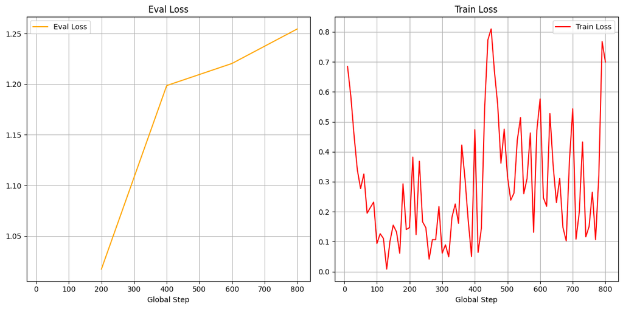

```python
plot_sft_results('nh58yhvw')
```

**Evaluation**

```python
res_ft_370_dpo = eval_model(model_370, tokenizer, ['arc_easy'])
print('Fine tuned: ',res_ft_370_dpo['results'])
```

Mamba 370m fine-tuned with DPO:

```
{'arc_easy': {'alias': 'arc_easy', 'acc,none': 0.6069023569023569, 'acc_stderr,none': 0.010022540618945322, 'acc_norm,none': 0.6056397306397306, 'acc_norm_stderr,none': 0.010028176038392816
}}
```

### 790m

```python
res_790_arc_e = eval_model(model_790, tokenizer, ['arc_easy'])
print(f'Risultati modello base ({model_790.dtype}): {res_790_arc_e["results"]}')
```

Results base model (torch.float32):

```
{'arc_easy': {'alias': 'arc_easy', 'acc,none': 0.6123737373737373, 'acc_stderr,none': 0.009997307914447627, 'acc_norm,none': 0.5382996632996633, 'acc_norm_stderr,none': 0.010229639820610701}}
```

#### SFT

```python
dir_790_sft_arce = "/content/drive/MyDrive/mamba2/mamba-790m-arce-sft-v2"

params_790m_sft = PersonalizedParams(
    output_dir=dir_790_sft_arce,
    eval_steps=50,
    save_steps=2,
    batch_size=4,
    gradient_accumulation_steps=2,
    learning_rate=4e-05,
    weight_decay=0.01,
    warmup_ratio=0.05,
    lr_scheduler_type = 'cosine',

)

params_790m_sft
```

```python
trainer_790m_sft = PersonalizedTrainer(
    model = model_790,
    strategy='sft',
    params=params_790m_sft,
    early_stopping_patience = 3
)

trainer_790m_sft
```

```python
finetuner_790_sft = MambaFineTuner(new_dataset_arc_e, trainer_790m_sft)
finetuner_790_sft.tune(save=dir_790_sft_arce)
```

Run id: t6z0sbp8

Run duration: 0:44:26

| Epoch | Step | Train Loss | Eval Loss |
| --- | --- | --- | --- |
| 0.1776 | 50 | 5.7228 | 2.8669 |
| 0.3552 | 100 | 5.5352 | 2.694 |
| 0.5329 | 150 | 5.2522 | 2.619 |
| 0.7105 | 200 | 5.2319 | 2.5744 |
| 0.8881 | 250 | 4.8375 | 2.5443 |
| 1.0639 | 300 | 4.7256 | 2.5218 |
| 1.2416 | 350 | 4.5013 | 2.5097 |
| 1.4192 | 400 | 4.7768 | 2.5004 |
| 1.5968 | 450 | 4.594 | 2.4945 |
| 1.7744 | 500 | 4.6066 | 2.4922 |
| 1.952 | 550 | 4.6453 | 2.4887 |
| 2.1279 | 600 | 4.357 | 2.4867 |
| 2.3055 | 650 | 4.4674 | 2.4847 |
| 2.4831 | 700 | 4.5862 | 2.486 |
| 2.6607 | 750 | 4.5147 | 2.4857 |
| 2.8384 | 800 | 4.5844 | 2.4867 |

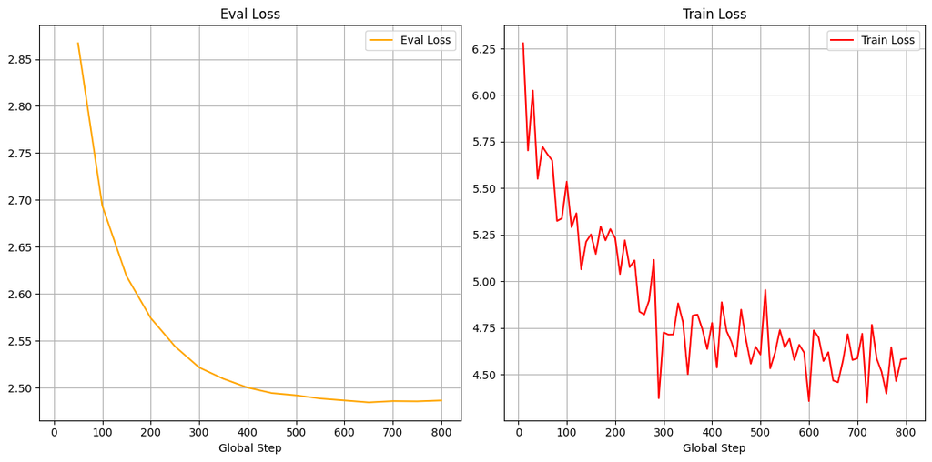

```python
plot_sft_results('t6z0sbp8')
```

**Evaluation**

```python
res_790 = eval_model(model_790, tokenizer, ['arc_easy'])
print('Fine tuned: ',res_790['results'])
```

Mamba 790m fine-tuned with SFT:

```
{'arc_easy': {'alias': 'arc_easy', 'acc,none': 0.6372053872053872, 'acc_stderr,none': 0.009865936757013891, 'acc_norm,none': 0.6279461279461279, 'acc_norm_stderr,none': 0.009918187193096445}}
```

#### DPO

```python
dir_790_sft_arce = "/content/drive/MyDrive/mamba2/mamba-790m-arce-dpo-v2"

params_790m_dpo = PersonalizedParams(
    output_dir=dir_790_sft_arce,
    eval_steps=250,
    save_steps=2,
    batch_size=2,
    gradient_accumulation_steps=4,
    learning_rate=4e-05,
    weight_decay=0.01,
    warmup_ratio=0.05,
    lr_scheduler_type = 'cosine',
    metric_for_best_model='rewards/accuracies'
)


params_790m_dpo.set_param('save_safetensors', False)

params_790m_dpo
```

```python
trainer_790m_dpo = PersonalizedTrainer(
    model = model_790,
    strategy='dpo',
    params=params_790m_dpo,
    early_stopping_patience = 3
)

trainer_790m_dpo
```

```python
finetuner_790_dpo = MambaFineTuner(new_dataset_arc_e, trainer_790m_dpo)
finetuner_790_dpo.tune(save=dir_790_sft_arce)
```

[output not shown]

**Evaluation**

```python
res_ft_790_dpo = eval_model(finetuner_790_dpo, tokenizer, ['arc-easy'])
print('Fine tuned: ',res_ft_790_dpo['results'])
```

[output not shown]

### 1.4b sft

```python
dir_1400_sft_lora = "/content/drive/MyDrive/mamba2/arce/mamba-1.4b-piqa-sft-lora"

params_1400m_sft_lora = PersonalizedParams(
    output_dir=dir_1400_sft_lora,
    eval_steps=50,
    save_steps=2,
    batch_size=4,
    gradient_accumulation_steps=16,
    num_train_epochs=3
)
params_1400m_sft_lora.set_param('fp16', True)

params_1400m_sft_lora
```

```python
trainer_1400m_sft_lora = PersonalizedTrainer(
    model = model_1400,
    strategy='sft',
    params=params_1400m_sft_lora,
    early_stopping_patience = 5,
    peft_config = peft_config
)
```

```python
res_1400_ft_sft_lora = eval_model(model_1400, tokenizer, ['arc_easy'])
print('Fine tuned:', res_1400_ft_sft_lora['results'])
```

Mamba 1.4b fine-tuned with LoRA and SFT:

[output not shown]

# Results and final comments

- Full results table can be found [here](https://docs.google.com/spreadsheets/d/1BP_IjWKOd1V5yaf_Is5UwXBkKpxoxz7bTbljlQgRaKo/edit?gid=1864727609#gid=1864727609)
- We focus here on a subset of results relevant to our initial experimental goals.

## PIQA

**Full Fine-Tuning**

| Model | Dtype | Trainer | Accuracy (base) | Accuracy (FT) |
| --- | --- | --- | --- | --- |
| mamba 130m | bf16 | SFT | 64.47% | 67.35% |
| mamba 130m | bf16 | DPO | 64.47% | 65.13% |
| mamba 130m | fp32 | SFT | 64.47% | 68.06% |
| mamba 130m | fp32 | DPO | 64.47% | 68.44% |
| mamba 370m | fp32 | SFT | 69.47% | 73.12% |
| mamba 370m | fp32 | DPO | 69.47% | 76.17% |
| mamba 790m | bf16 | SFT | 72.14% | 73,39% |
| mamba 790m | bf16 | DPO | 72.14% | 75,35% |

- The best model is the 370 million parameters Mamba
  - Fine-tuned with the DPO Trainer, got better results than the Mamba 2.8 billion parameters, the biggest Mamba model.
  - The Mamba 370M fine-tuned with DPO results are even comparable with Mamba2 2.7 billion parameters. Again, the biggest Mamba2 model.
- The mamba 790M here was our upper bound due to the environment constraint. We had to rely on the `torch.bfloat16` precision and we could not try much hyperparameters search.

**LoRA Fine-Tuning**

[output not shown]

**Observations**

**Hyperparameter tuning** played a critical role in maximizing performance:

- **Learning rate:** strongly influenced adaptation speed and stability.
- **Weight decay:** optimal values clustered around **0.01**.
- **Warmup ratio:** effective around **10% ± 5%** of total steps.

The choice of **evaluation metric** depended on the training strategy:

- For **SFT**, we relied on *validation loss*, reflecting generalization ability.
- For **DPO**, we monitored *rewards/accuracies* (fraction of chosen rewards exceeding rejected ones), while also checking validation loss and reward margins to detect overfitting.

Several important insights emerged from our **LoRA experiments**:

Overall, results indicate that **LoRA scales more effectively with larger architectures**:

- For small models, LoRA underperforms compared to full fine-tuning.
- For large models, LoRA achieves results equal to or better than full fine-tuning.

## ARC-E

**Full Fine-Tuning**

[output not shown]

**Observations**

**Summary:**

## Final Comments

- This work demonstrates that **fine-tuning can substantially reduce computational and memory requirements** while still achieving competitive performance on benchmark datasets.
- Key finding:
  - The **Mamba 370M** model (~1.5 GB) was able to **match or surpass** the performance of the much larger **2.8B model** (~11 GB).
  - This highlights the potential of **fine-tuned smaller models** as practical alternatives to significantly larger architectures.
- Consistency across experiments:
  - Fine-tuning often enabled a model to perform at the level of the **next parameter tier**:
  - Fine-tuned **Mamba 130M** ≈ baseline **370M**
  - Fine-tuned **Mamba 370M** ≈ baseline **790M**
  - Fine-tuned **Mamba 790M** ≈ baseline **1.4B / 2.8B**
  - This demonstrates the **effectiveness of fine-tuning** as a strategy to enhance efficiency **without adding parameters**.
- Main insight:
  - The **choice of fine-tuning technique often matters more than raw model size**.
  - Even within constrained environments like **Google Colab**, carefully chosen fine-tuning methods unlocked **significant performance gains**.
  - This enables the deployment of **capable models on less powerful hardware**, without compromising accuracy or efficiency.

# Future work

A direction for future work is a deeper exploration of **Mamba 2**, the next-generation state space model architecture.

- **Key innovations in Mamba 2:**
  - Leverages **State Space Duality (SSD)**: the state transition matrix is reduced to a scalar-times-identity form.
    - Preserves the ability to model **long-range dependencies**.
    - Enables **2–8× faster computation** compared to the original Mamba design.
  - Introduces **parallel parameter computation**, **grouped projections**, and **efficient tensor parallelism**, improving scalability in resource-constrained environments.
- These improvements suggest that **Mamba 2** could be a strong candidate for **fine-tuning and deployment on limited hardware**, while remaining competitive with Transformer-based approaches.

Another important direction is to extend fine-tuning beyond supervised and preference-based approaches, by exploring **reinforcement learning-based methods**, such as **GRPO** and **PPO**:

- **GRPO (Guided Reinforcement Policy Optimization):**
  - Online learning algorithm that iteratively improves using data generated by the model itself.
  - Objective: maximize the advantage of generated completions while keeping the policy close to a reference, balancing **exploration and stability**.
- **PPO (Proximal Policy Optimization):**
  - Policy-gradient method that improves learning stability.
  - Uses a **clipped surrogate objective** to limit policy changes per update.

Investigating **integration of GRPO and PPO with Mamba and Mamba 2** could:

- Provide insights into how state space architectures respond to **reinforcement-driven optimization**.
- Assess whether **efficiency advantages** of Mamba architectures extend to more complex training paradigms.

# References

1. Albert Gu, Tri Dao. 1 Dec 2023. *"Mamba: Linear-Time Sequence Modeling with Selective State Spaces"*. [arxiv 2312.00752](https://arxiv.org/abs/2312.00752).
2. AI Coffee Break with Letitia. 17 Feb 2024. "[MAMBA and State Space Models explained | SSM explained](https://youtu.be/vrF3MtGwD0Y)". YouTube.
3. Algorithmic Simplicity. 1 May 2024."[MAMBA from Scratch: Neural Nets Better and Faster than Transformers](https://www.youtube.com/watch?v=N6Piou4oYx8&t=1313s)". YouTube.
4. Yannic Kilcher. 24 Dec 2023. "[Mamba: Linear-Time Sequence Modeling with Selective State Spaces (Paper Explained)](https://www.youtube.com/watch?v=9dSkvxS2EB0)". YouTube.
5. Maarten Grootendorst."[A Visual Guide to Mamba and State Space Models](https://newsletter.maartengrootendorst.com/p/a-visual-guide-to-mamba-and-state)". Last accessed: 2 Sep 2025.
6. Dave Bergmann. [What is a Mamba Model?|IBM](https://www.ibm.com/think/topics/mamba-model). Last access 5 Sep 2025.
7. Nvidia Developer. "[Scan algorithm (NVIDIA)](https://developer.nvidia.com/gpugems/gpugems3/part-vi-gpu-computing/chapter-39-parallel-prefix-sum-scan-cuda)". Last access 15 Jul 2025.
8. Stella Biderman, Hailey Schoelkopf, Lintang Sutawika, Leo Gao, Jonathan Tow, Baber Abbasi, Alham Fikri Aji, Pawan Sasanka Ammanamanchi, Sidney Black, Jordan Clive, Anthony DiPofi, Julen Etxaniz, Benjamin Fattori, Jessica Zosa Forde, Charles Foster, Jeffrey Hsu, Mimansa Jaiswal, Wilson Y. Lee, Haonan Li, Charles Lovering, Niklas Muennighoff, Ellie Pavlick, Jason Phang, Aviya Skowron, Samson Tan, Xiangru Tang, Kevin A. Wang, Genta Indra Winata, François Yvon, Andy Zou. *"Lessons from the Trenches on Reproducible Evaluation of Language Models*". 29 May 2024. [arxiv 2405.14782](https://arxiv.org/abs/2405.14782)
9. Eluther AI. [Evaluating LLMs](https://www.eleuther.ai/projects/large-language-model-evaluation). Last access: 31 Aug 2025.
10. Eluther AI. [GitHub lm-evaluation-harness](https://github.com/EleutherAI/lm-evaluation-harness). Last access: 31 Aug 2025.
11. Hugging Face. [SFT Trainer](https://huggingface.co/docs/trl/sft_trainer). Last access: 27 Aug 2025.
12. Hugging Face. [DPO Trainer](https://huggingface.co/docs/trl/en/dpo_trainer). Last access: 27 Aug 2025.
13. Rafael Rafailov, Archit Sharma, Eric Mitchell, Stefano Ermon, Christopher D. Manning, Chelsea Finn. 29 Jul 2024. *"# Direct Preference Optimization: Your Language Model is Secretly a Reward Model"*. [arxiv 2305.18290](https://arxiv.org/abs/2305.18290).
14. Hugging Face. [LoRA](https://huggingface.co/docs/peft/main/conceptual_guides/lora). Last access: 28 Aug 2025.
15. Edward J. Hu, Yelong Shen, Phillip Wallis, Zeyuan Allen-Zhu, Yuanzhi Li, Shean Wang, Lu Wang, Weizhu Chen.*"LoRA: Low-Rank Adaptation of Large Language Models"*. [arxiv 2106.09685](https://arxiv.org/abs/2106.09685)
16. Mark Hennings. 14 Dec 2023. "[LoRA & QLoRA Fine-tuning Explained In-Depth](https://www.youtube.com/watch?v=t1caDsMzWBk)". YouTube.
17. Venkatesh Balavadhani Parthasarathy, Ahtsham Zafar, Aafaq Khan, Arsalan Shahid. 30 Oct 2024. *"The Ultimate Guide to Fine-Tuning LLMs from Basics to Breakthroughs: An Exhaustive Review of Technologies, Research, Best Practices, Applied Research Challenges and Opportunities"*. [arxiv 2408.13296](https://arxiv.org/abs/2408.13296).
18. Hugging Face. [Mamba](https://huggingface.co/docs/transformers/main/model_doc/mamba). Last access: 18 Aug 2025.
19. state-spaces. [GitHub mamba](https://github.com/state-spaces/mamba). Last access: 30 Jul 2025.
20. Dao-AILab. [GitHub causal-conv1d](https://github.com/Dao-AILab/causal-conv1d). Last access: 30 Jul 2025.
21. Tri Dao, Albert Gu. 31 May 2024. *"Transformers are SSMs: Generalized Models and Efficient Algorithms Through Structured State Space Duality"*. [arxiv 2405.21060](https://arxiv.org/abs/2405.21060).

End of the notebook! :D

Tanks for reading.